# WGU Analysis

## *Part II* - Exploratory Analysis

#### By: Hayden Allison | 2/11/2024

#### Highlights: Machine Learning Algorithms & Statistical Modelling & Feature Engineering

#### Population: Prosper Loan Batch (113,066 records)

This extension of the original analysis serves to implement an appropriate statistical model in answering a more refined research question where practical significance can be identified. A second research question that drives business value for Prosper is also added. This is achieved from predicting the outcome of loans applications, which boosts revenue and mitigates risk of loan approval decision-making. A deployable machine learning algorithm is developed for this prediction task.

### Research Question 1:

Are classifications or measurements evaluated by Prosper regarding loan applicants utilized in alotting them conditions?

##### Null Hypothesis: Uniform average/median for the class.

##### Alternate Hypothesis: The average/median of loan conditions (APR and amount) is relative to class members.

### Research Question 2:

Can loan outcomes be predicted for new customers who apply?

```python
import pandas as pd
import numpy as np
import matplotlib.pyplot as plt
import seaborn as sns
import sklearn as sk
from astropy.stats import knuth_bin_width, bayesian_blocks
from scipy import stats
from sklearn.preprocessing import StandardScaler, OneHotEncoder, OrdinalEncoder, RobustScaler, LabelEncoder
from sklearn.model_selection import train_test_split, cross_val_predict, cross_val_score, KFold, StratifiedKFold
from sklearn.model_selection import GridSearchCV, RandomizedSearchCV
from sklearn.metrics import accuracy_score, recall_score, precision_score, f1_score
from sklearn import set_config
from sklearn.ensemble import RandomForestClassifier, AdaBoostClassifier
from sklearn.neighbors import KNeighborsClassifier
from sklearn.tree import DecisionTreeClassifier
from sklearn.linear_model import LogisticRegression
from sklearn.multioutput import MultiOutputClassifier
from xgboost import XGBClassifier
from sklearn.naive_bayes import GaussianNB
from lightgbm import LGBMClassifier
from scipy.stats import levene, kruskal, f_oneway
from scikit_posthocs import posthoc_dunn, posthoc_conover
from matplotlib.font_manager import FontProperties
import warnings

warnings.filterwarnings("ignore", category=FutureWarning)
warnings.filterwarnings("ignore", category=UserWarning)

# removes copy warning
pd.options.mode.chained_assignment = None

set_config(transform_output = 'pandas')
pd.set_option('display.precision', 3)

# for all statistic modelling
alpha = 0.05
```

## Data Preparation

```python
# Importing tables from Part I Analysis
credit_df = pd.read_csv(r'C:\Users\tekre\Downloads\Analysis Projects\10022023_Loans_Analysis\Tables\credit_table.csv')
customer_df = pd.read_csv(r'C:\Users\tekre\Downloads\Analysis Projects\10022023_Loans_Analysis\Tables\customer_table.csv')
loan_df = pd.read_csv(r'C:\Users\tekre\Downloads\Analysis Projects\10022023_Loans_Analysis\Tables\loan_table.csv')
mega_df = pd.read_csv(r'C:\Users\tekre\Downloads\Analysis Projects\10022023_Loans_Analysis\Tables\mega_table.csv')
```

```python
anova_df = mega_df[['IncomeRange', 'CreditScoreRangeLower', 'CreditScoreRangeUpper', 'LoanOriginalAmount', 'BorrowerAPR']]
anova_df.head(5)
```

|  | IncomeRange | CreditScoreRangeLower | CreditScoreRangeUpper | LoanOriginalAmount | BorrowerAPR |
| --- | --- | --- | --- | --- | --- |
| 0 | $25,000-49,999 | 640.0 | 659.0 | 9425 | 0.165 |
| 1 | $50,000-74,999 | 680.0 | 699.0 | 10000 | 0.120 |
| 2 | $25,000-49,999 | 480.0 | 499.0 | 3001 | 0.283 |
| 3 | $100,000+ | 800.0 | 819.0 | 10000 | 0.125 |
| 4 | $100,000+ | 680.0 | 699.0 | 15000 | 0.246 |

The Credit Score columns need to be an ordinal qualitative variable so brackets are being implemented. This is done according to the FICO credit model instead of VantageScore since it wins in popularity - that documentation of variables doesn't clarify which model the scores are based from. Also note how there is 2 credit score features. A dervied variable is going into a single feature for use in testing thats the average between the 2 scores, for each customer.

```python
# Creating a single derived variable
anova_df.loc[:, 'CreditScore'] = round((anova_df.loc[:, 'CreditScoreRangeUpper']+anova_df.loc[:, 'CreditScoreRangeLower'])/2, 0)
anova_df.drop(['CreditScoreRangeUpper', 'CreditScoreRangeLower'], axis=1, inplace=True)
```

```python
# replacing scores into ratings
def credit_rates(df):
    edit_df = df.copy()
    ratings = []
    for score in df['CreditScore']:
        if score <= 579:
            ratings.append('Poor')
        elif score > 579 and score <= 669:
            ratings.append('Fair')
        elif score > 669 and score <= 739:
            ratings.append('Good')
        elif score > 739 and score <= 799:
            ratings.append('Very Good')
        else:
            ratings.append('Exceptional')
    edit_df.loc[:, 'CreditScore'] = ratings
    return edit_df

anova_df = credit_rates(anova_df)

# Establishing ordinal status for credit rating
credit_ranks = ['Poor', 'Fair', 'Good', 'Very Good', 'Exceptional']
credit_ratings = pd.CategoricalDtype(categories=credit_ranks, ordered=True)
anova_df['CreditScore'] = anova_df['CreditScore'].astype(credit_ratings)

# Establishing ordinal status for income range
income_ranks = ['$0', '$1-24,999', '$25,000-49,999', '$50,000-74,999', '$75,000-99,999', '$100,000+']
income_ranges = pd.CategoricalDtype(categories=income_ranks, ordered=True)
anova_df['IncomeRange'] = anova_df['IncomeRange'].astype(income_ranges)
```

```python
anova_df.isna().sum()
```

```
IncomeRange           0
LoanOriginalAmount    0
BorrowerAPR           0
CreditScore           0
dtype: int64
```

```python
# beautiful chart settings
custom_params = {"axes.spines.right": False, "axes.spines.top": False, 'font.size': 11, 'axes.titlesize': 14,
                'axes.titlepad': 20}
sns.set(style='darkgrid', palette='rocket_r', font='monospace', rc=custom_params)
```

## Research Question 1: Credit Rating Statistic Model

```python
# Test 1: Credit Score by Loan Amount
test_1_poor = np.array(anova_df.loc[anova_df['CreditScore']=='Poor', 'LoanOriginalAmount'])
test_1_fair = np.array(anova_df.loc[anova_df['CreditScore']=='Fair', 'LoanOriginalAmount'])
test_1_good = np.array(anova_df.loc[anova_df['CreditScore']=='Good', 'LoanOriginalAmount'])
test_1_verygood = np.array(anova_df.loc[anova_df['CreditScore']=='Very Good', 'LoanOriginalAmount'])
test_1_exceptional = np.array(anova_df.loc[anova_df['CreditScore']=='Exceptional', 'LoanOriginalAmount'])

# Test 2: Credit Score by APR
test_2_poor = np.array(anova_df.loc[anova_df['CreditScore']=='Poor', 'BorrowerAPR'])
test_2_fair = np.array(anova_df.loc[anova_df['CreditScore']=='Fair', 'BorrowerAPR'])
test_2_good = np.array(anova_df.loc[anova_df['CreditScore']=='Good', 'BorrowerAPR'])
test_2_verygood = np.array(anova_df.loc[anova_df['CreditScore']=='Very Good', 'BorrowerAPR'])
test_2_exceptional = np.array(anova_df.loc[anova_df['CreditScore']=='Exceptional', 'BorrowerAPR'])
```

### Time to evaluate for normal distribution of dependent variables (Loan Amount & APR)

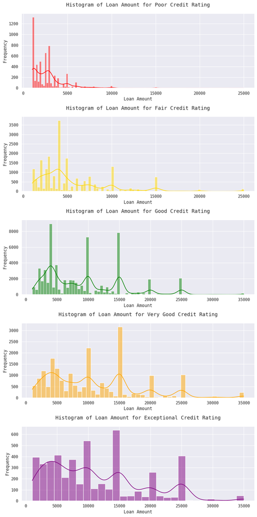

```python
# initializing bins
bins_1_poor = np.histogram_bin_edges(test_1_poor, bins='auto')
bins_1_fair = np.histogram_bin_edges(test_1_fair, bins='auto')
bins_1_good = np.histogram_bin_edges(test_1_good, bins='auto')
bins_1_verygood = np.histogram_bin_edges(test_1_verygood, bins='auto')
bins_1_exceptional = np.histogram_bin_edges(test_1_exceptional, bins='auto')

fig, axs = plt.subplots(5, 1, figsize=(10, 20))

# PLot histrograms for each credit rating
sns.histplot(test_1_poor, bins=bins_1_poor, color='red', alpha=0.5, kde=True, ax=axs[0])
axs[0].set_title('Histogram of Loan Amount for Poor Credit Rating')
axs[0].set_xlabel('Loan Amount')
axs[0].set_ylabel('Frequency')

sns.histplot(test_1_fair, bins=bins_1_fair, color='gold', alpha=0.5, kde=True, ax=axs[1])
axs[1].set_title('Histogram of Loan Amount for Fair Credit Rating')
axs[1].set_xlabel('Loan Amount')
axs[1].set_ylabel('Frequency')

sns.histplot(test_1_good, bins=bins_1_good, color='green', alpha=0.5, kde=True, ax=axs[2])
axs[2].set_title('Histogram of Loan Amount for Good Credit Rating')
axs[2].set_xlabel('Loan Amount')
axs[2].set_ylabel('Frequency')

sns.histplot(test_1_verygood, bins=bins_1_verygood, color='orange', alpha=0.5, kde=True, ax=axs[3])
axs[3].set_title('Histogram of Loan Amount for Very Good Credit Rating')
axs[3].set_xlabel('Loan Amount')
axs[3].set_ylabel('Frequency')

sns.histplot(test_1_exceptional, bins=bins_1_exceptional, color='purple', alpha=0.5, kde=True, ax=axs[4])
axs[4].set_title('Histogram of Loan Amount for Exceptional Credit Rating')
axs[4].set_xlabel('Loan Amount')
axs[4].set_ylabel('Frequency')

plt.tight_layout()
plt.show()
```

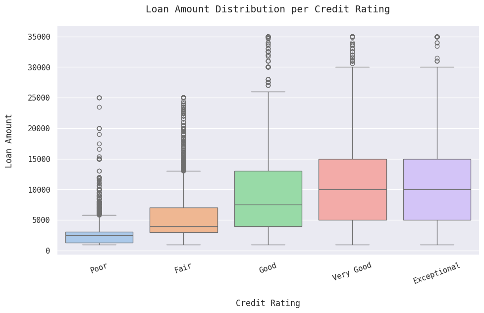

```python
plt.figure(figsize=(11,6))
sns.boxplot(data=anova_df, x='CreditScore', y='LoanOriginalAmount', palette='pastel')
plt.xticks(rotation=20)
plt.title('Loan Amount Distribution per Credit Rating')
plt.xlabel('Credit Rating', labelpad=20)
plt.ylabel('Loan Amount', labelpad=20)
plt.show()
```

These distributions are positively skewed and don't follow empiricule rule which indicates tests with condition of Guassian distributions can't be used - from the bottom side median and top side outliers in box plot and the shape & spread of histrogram.

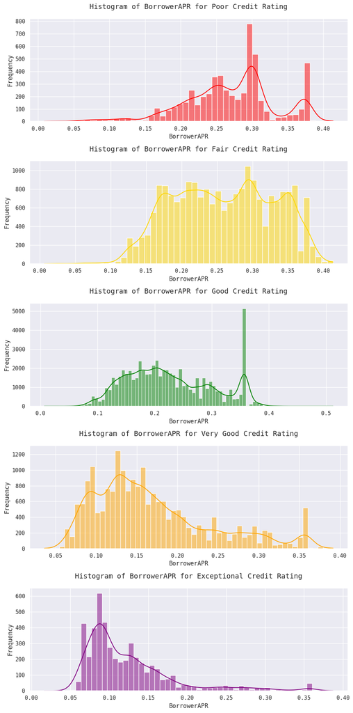

```python
# initializing bins
bins_2_poor = np.histogram_bin_edges(test_2_poor, bins='auto')
bins_2_fair = np.histogram_bin_edges(test_2_fair, bins='auto')
bins_2_good = np.histogram_bin_edges(test_2_good, bins='auto')
bins_2_verygood = np.histogram_bin_edges(test_2_verygood, bins='auto')
bins_2_exceptional = np.histogram_bin_edges(test_2_exceptional, bins='auto')

fig, axs = plt.subplots(5, 1, figsize=(10, 20))

# Plot histograms for each credit rating
sns.histplot(test_2_poor, bins=bins_2_poor, color='red', alpha=0.5, kde=True, ax=axs[0])
axs[0].set_title('Histogram of BorrowerAPR for Poor Credit Rating')
axs[0].set_xlabel('BorrowerAPR')
axs[0].set_ylabel('Frequency')

sns.histplot(test_2_fair, bins=bins_2_fair, color='gold', alpha=0.5, kde=True, ax=axs[1])
axs[1].set_title('Histogram of BorrowerAPR for Fair Credit Rating')
axs[1].set_xlabel('BorrowerAPR')
axs[1].set_ylabel('Frequency')

sns.histplot(test_2_good, bins=bins_2_good, color='green', alpha=0.5, kde=True, ax=axs[2])
axs[2].set_title('Histogram of BorrowerAPR for Good Credit Rating')
axs[2].set_xlabel('BorrowerAPR')
axs[2].set_ylabel('Frequency')

sns.histplot(test_2_verygood, bins=bins_2_verygood, color='orange', alpha=0.5, kde=True, ax=axs[3])
axs[3].set_title('Histogram of BorrowerAPR for Very Good Credit Rating')
axs[3].set_xlabel('BorrowerAPR')
axs[3].set_ylabel('Frequency')

sns.histplot(test_2_exceptional, bins=bins_2_exceptional, color='purple', alpha=0.5, kde=True, ax=axs[4])
axs[4].set_title('Histogram of BorrowerAPR for Exceptional Credit Rating')
axs[4].set_xlabel('BorrowerAPR')
axs[4].set_ylabel('Frequency')

plt.tight_layout()
plt.show()
```

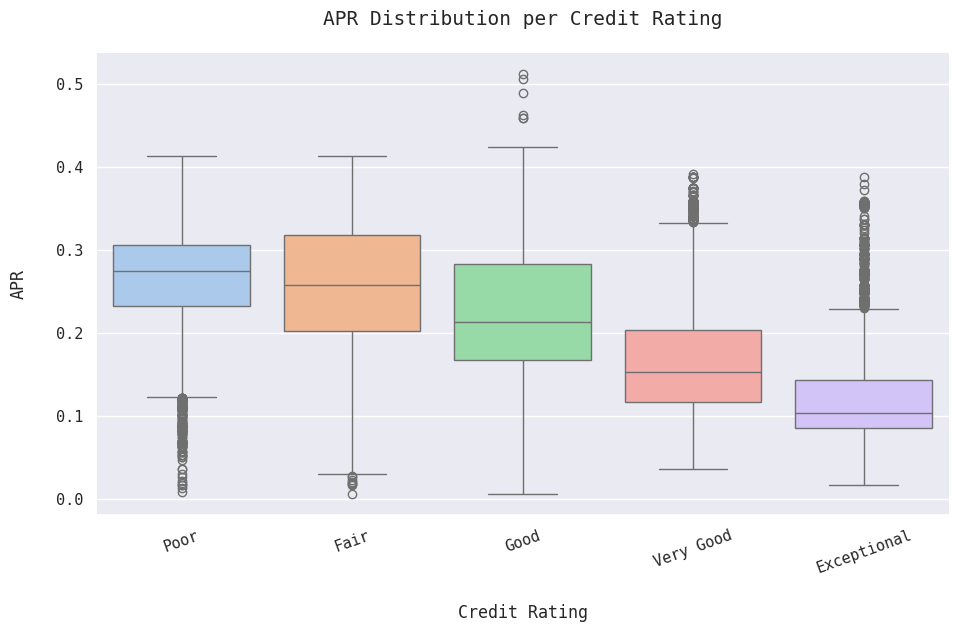

```python
plt.figure(figsize=(11,6))
sns.boxplot(data=anova_df, x='CreditScore', y='BorrowerAPR', palette='pastel')
plt.xticks(rotation=20)
plt.title('APR Distribution per Credit Rating')
plt.xlabel('Credit Rating', labelpad=20)
plt.ylabel('APR', labelpad=20)
plt.show()
```

### Creating Test 1 & 2 Samples for Statistical Modelling

```python
# Since Credit Score isn't depdenent on Amount/APR, tests 1 and 2 have groups of equal size
print('Sizes (N) of Loan Amount/APR by Credit Rating')
print('Poor:', len(test_1_poor))
print('Fair:', len(test_1_fair))
print('Good:', len(test_1_good))
print('Very Good:', len(test_1_verygood))
print('Exceptional:', len(test_1_exceptional))
```

```
Sizes (N) of Loan Amount/APR by Credit Rating
Poor: 5641
Fair: 20997
Good: 61195
Very Good: 20384
Exceptional: 4849
```

```python
# Original groups are being filtered to eliminate outliers
test_groups = [test_1_poor, test_1_fair, test_1_good, test_1_verygood, test_1_exceptional]
test_groups_filtered = [list(filter(lambda x: x <= 14999, group)) for group in test_groups]
test_group_poor, test_group_fair, test_group_good, test_group_verygood, test_group_exceptional = test_groups_filtered
```

A loan amount for 14,999 was chosen as the cut off. This preserves the deviation of higher ranked categories more when compared to 10,000. 14,999 avoids the few 15,000 outliers in Poor - who's outliers don't disrupt the model's median analysis and reflect genuine values so leaving them included is preferred over introducing sampling bias. The box plot's relationships & median accurately reflect the population.

```python
# Test 1 samples
np.random.seed(22)
test_sample_p = np.random.choice(test_group_poor, size=4845)
test_sample_f = np.random.choice(test_group_fair, size=4845)
test_sample_g = np.random.choice(test_group_good, size=4845)
test_sample_vg = np.random.choice(test_group_verygood, size=4845)
test_sample_e = np.random.choice(test_group_exceptional, size=4845)
```

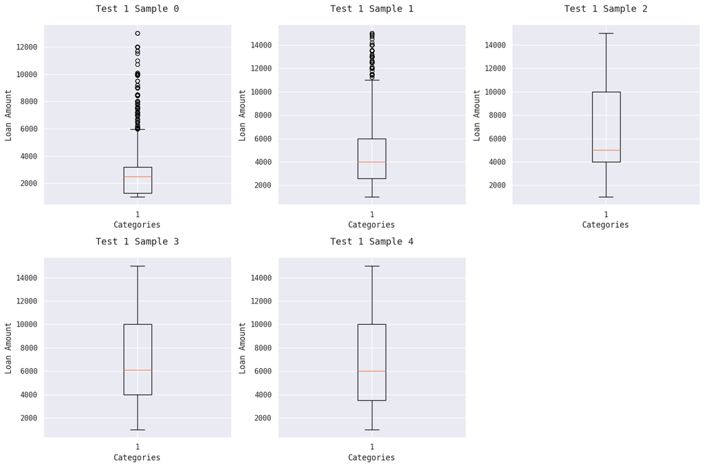

```python
# Box plots for estimating variance and no outliers validation
test_samples = [test_sample_p, test_sample_f, test_sample_g, test_sample_vg, test_sample_e]

fig, axs = plt.subplots(2, 3, figsize=(15, 10))

# Flatten the axs array to iterate easily
axs = axs.flatten()

for i, (sample, ax) in enumerate(zip(test_samples, axs)):
    ax.boxplot(sample)
    ax.set_title(f'Test 1 Sample {i}')
    ax.set_ylabel('Loan Amount')
    ax.set_xlabel('Categories')

fig.delaxes(axs[-1])
plt.tight_layout()
plt.show()
```

```python
# Original groups are being filtered to eliminate outliers
test2_groups = [test_2_poor, test_2_fair, test_2_good, test_2_verygood, test_2_exceptional]
test2_groups_filtered = [list(filter(lambda x: x <= .4, group)) for group in test2_groups]
test2_group_poor, test2_group_fair, test2_group_good, test2_group_verygood, test2_group_exceptional = test2_groups_filtered
```

An APR for 0.4 was chosen as the cut off. This eliminates noise from outliers while preserving the original deviation. These outliers reflect genuine values and don't disrupt the model's median analysis. The box plot's relationships & median accurately reflect the population.

```python
# Test 2 samples
np.random.seed(23)
test2_sample_p = np.random.choice(test2_group_poor, size=4845)
test2_sample_f = np.random.choice(test2_group_fair, size=4845)
test2_sample_g = np.random.choice(test2_group_good, size=4845)
test2_sample_vg = np.random.choice(test2_group_verygood, size=4845)
test2_sample_e = np.random.choice(test2_group_exceptional, size=4845)
```

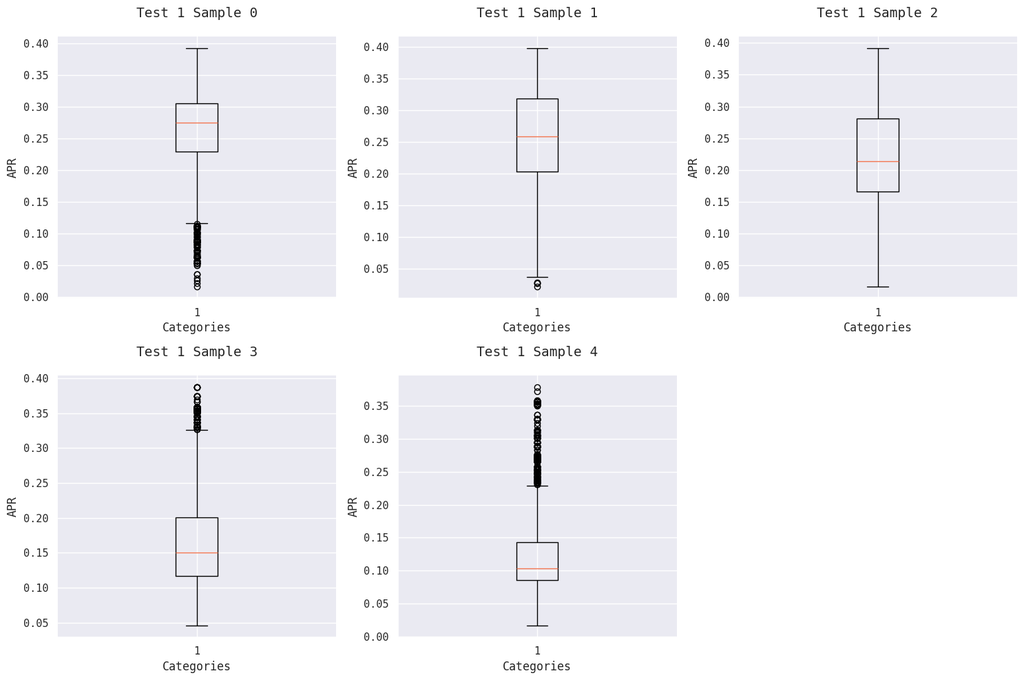

```python
# Box plots for estimating variance and no outliers validation
test2_samples = [test2_sample_p, test2_sample_f, test2_sample_g, test2_sample_vg, test2_sample_e]

fig, axs = plt.subplots(2, 3, figsize=(15, 10))

# Flatten the axs array to iterate easily
axs = axs.flatten()

for i, (sample, ax) in enumerate(zip(test2_samples, axs)):
    ax.boxplot(sample)
    ax.set_title(f'Test 1 Sample {i}')
    ax.set_ylabel('APR')
    ax.set_xlabel('Categories')

fig.delaxes(axs[-1])
plt.tight_layout()
plt.show()
```

This is confirmation of non-homoscedastic groups. Invalidates the option to run ANOVA tests.

### Test 1 - Kursal Wallis

```python
statistic, p_value = kruskal(test_sample_p, test_sample_f, test_sample_g, test_sample_vg, test_sample_e)
print("statistic:", round(statistic, 3))
print("P-value:", round(p_value, 2))

if p_value <= alpha:
    print("Reject the null hypothesis. There is a significant difference between at least two group medians.")
else:
    print("Fail to reject the null hypothesis. There is no significant difference between group medians.")
```

```
statistic: 5526.157
P-value: 0.0
Reject the null hypothesis. There is a significant difference between at least two group medians.
```

### Results

The results indicate further testing with a Post Hoc test since there is statistical signficance detected.

### Test 2 - Kursal Wallis

```python
statistic, p_value = kruskal(test2_sample_p, test2_sample_f, test2_sample_g, test2_sample_vg, test2_sample_e)
print("statistic:", round(statistic, 3))
print("P-value:", round(p_value, 2))

if p_value <= alpha:
    print("Reject the null hypothesis. There is a significant difference between at least two group medians.")
else:
    print("Fail to reject the null hypothesis. There is no significant difference between group medians.")
```

```
statistic: 10468.13
P-value: 0.0
Reject the null hypothesis. There is a significant difference between at least two group medians.
```

### Results

The results indicate further testing with a Post Hoc test since there is statistical signficance detected. Credit Rating by APR is quoted as having the more intense relationships from the higher statistic value in Test 2 compared to Test 1.

### Checking for similar distributions to determine between Dunn's and Conover Iman Tests

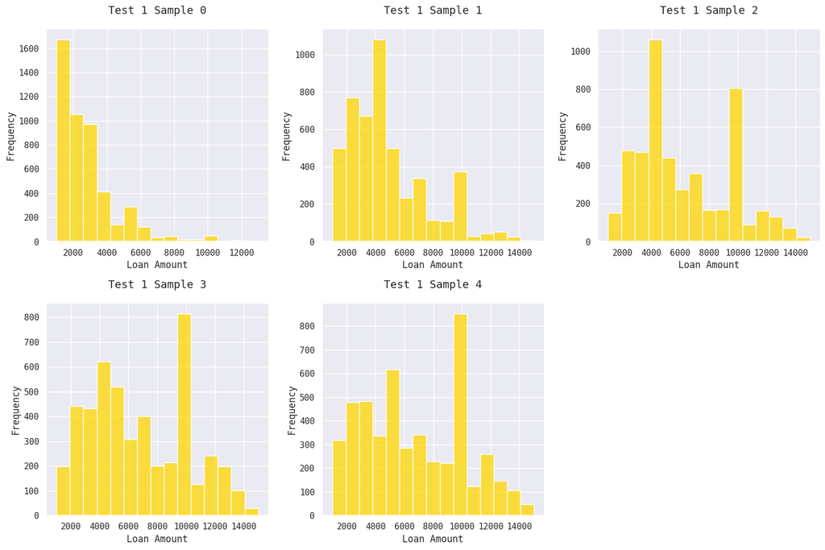

```python
# Test 1 sample distributions
fig, axs = plt.subplots(2, 3, figsize=(15, 10))

# Flatten the axs array to iterate easily
axs = axs.flatten()

for i, (sample, ax) in enumerate(zip(test_samples, axs)):
    sns.histplot(data=sample, ax=ax, color='gold', bins=15)
    ax.set_title(f'Test 1 Sample {i}')
    ax.set_ylabel('Frequency')
    ax.set_xlabel('Loan Amount')

fig.delaxes(axs[-1])

plt.tight_layout()
plt.show()
```

## Test 1 - Dunn Tests

```python
dunn_results = posthoc_dunn(test_samples, p_adjust='holm')
dunn_results <= .05
```

|  | 1 | 2 | 3 | 4 | 5 |
| --- | --- | --- | --- | --- | --- |
| 1 | False | True | True | True | True |
| 2 | True | False | True | True | True |
| 3 | True | True | False | True | True |
| 4 | True | True | True | False | False |
| 5 | True | True | True | False | False |

### Results

The comparison for Very Good between Exceptional Credit Rating don't report statistical significance - indicated by the "False" in col 4 row 5. This is unsurprising given similarities in spread, center, and shape in box plots and histograms.

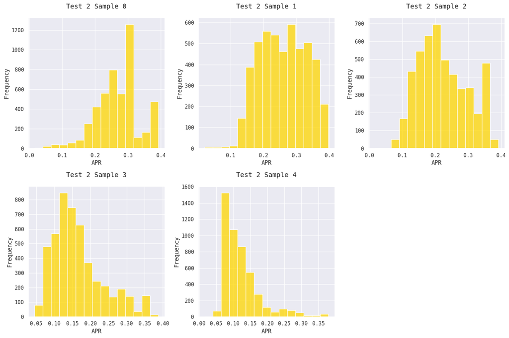

```python
# Test 2 sample distributions
fig, axs = plt.subplots(2, 3, figsize=(15, 10))

# Flatten the axs array to iterate easily
axs = axs.flatten()

for i, (sample, ax) in enumerate(zip(test2_samples, axs)):
    sns.histplot(data=sample, ax=ax, color='gold', bins=15)
    ax.set_title(f'Test 2 Sample {i}')
    ax.set_ylabel('Frequency')
    ax.set_xlabel('APR')

fig.delaxes(axs[-1])

plt.tight_layout()
plt.show()
```

## Test 2 - Conover-Iman Tests

The above histogram samples have varying skews, peaks, and symmetry levels. These attributes deviate from each other too much for Dunn Tests.

```python
conover_results = posthoc_conover(test2_samples, p_adjust='holm')
conover_results <= .05
```

|  | 1 | 2 | 3 | 4 | 5 |
| --- | --- | --- | --- | --- | --- |
| 1 | False | True | True | True | True |
| 2 | True | False | True | True | True |
| 3 | True | True | False | True | True |
| 4 | True | True | True | False | True |
| 5 | True | True | True | True | False |

### Results

The tests report statistical significance between all the Credit Rating values. This is expected due to how finanical institutions use credit score to determine applicant approval worthiness and allot the subsequent loan conditions.

## Research Question 1: Income Range Statistic Model

```python
# Test 3: Income Range by Loan Amount
test_3_0 = np.array(anova_df.loc[anova_df['IncomeRange']=='$0', 'LoanOriginalAmount'])
test_3_1 = np.array(anova_df.loc[anova_df['IncomeRange']=='$1-24,999', 'LoanOriginalAmount'])
test_3_25 = np.array(anova_df.loc[anova_df['IncomeRange']=='$25,000-49,999', 'LoanOriginalAmount'])
test_3_50 = np.array(anova_df.loc[anova_df['IncomeRange']=='$50,000-74,999', 'LoanOriginalAmount'])
test_3_75 = np.array(anova_df.loc[anova_df['IncomeRange']=='$75,000-99,999', 'LoanOriginalAmount'])
test_3_100 = np.array(anova_df.loc[anova_df['IncomeRange']=='$100,000+', 'LoanOriginalAmount'])

# Test 4: Income Range by APR
test_4_0 = np.array(anova_df.loc[anova_df['IncomeRange']=='$0', 'BorrowerAPR'])
test_4_1 = np.array(anova_df.loc[anova_df['IncomeRange']=='$1-24,999', 'BorrowerAPR'])
test_4_25 = np.array(anova_df.loc[anova_df['IncomeRange']=='$25,000-49,999', 'BorrowerAPR'])
test_4_50 = np.array(anova_df.loc[anova_df['IncomeRange']=='$50,000-74,999', 'BorrowerAPR'])
test_4_75 = np.array(anova_df.loc[anova_df['IncomeRange']=='$75,000-99,999', 'BorrowerAPR'])
test_4_100 = np.array(anova_df.loc[anova_df['IncomeRange']=='$100,000+', 'BorrowerAPR'])
```

### Time to evaluate for normal distribution of dependent variables (Loan Amount & APR)

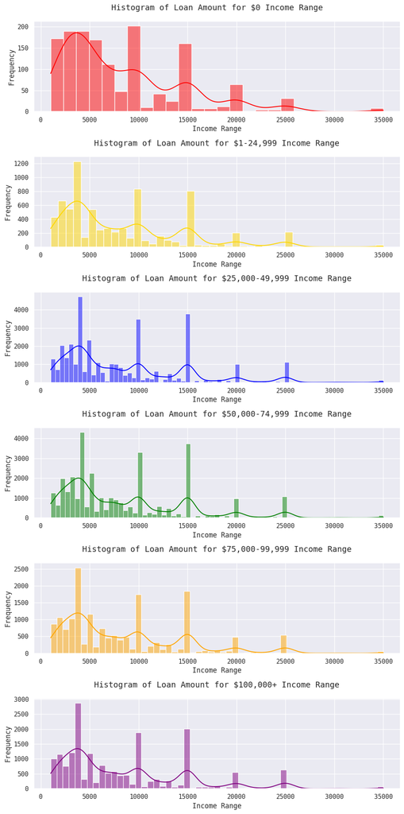

```python
# initializing bins
bins_0 = np.histogram_bin_edges(test_3_0, bins='auto')
bins_1 = np.histogram_bin_edges(test_3_1, bins='auto')
bins_25 = np.histogram_bin_edges(test_3_25, bins='auto')
bins_50 = np.histogram_bin_edges(test_3_50, bins='auto')
bins_75 = np.histogram_bin_edges(test_3_75, bins='auto')
bins_100 = np.histogram_bin_edges(test_3_100, bins='auto')

fig, axs = plt.subplots(6, 1, figsize=(10, 20))

# Plot histograms for Test 3
sns.histplot(test_3_0, color='red', alpha=0.5, bins=bins_0, kde=True, ax=axs[0])
axs[0].set_title('Histogram of Loan Amount for $0 Income Range')
axs[0].set_xlabel('Income Range')
axs[0].set_ylabel('Frequency')

sns.histplot(test_3_1, color='gold', alpha=0.5, bins=bins_1, kde=True, ax=axs[1])
axs[1].set_title('Histogram of Loan Amount for $1-24,999 Income Range')
axs[1].set_xlabel('Income Range')
axs[1].set_ylabel('Frequency')

sns.histplot(test_3_25, color='blue', alpha=0.5, bins=bins_25, kde=True, ax=axs[2])
axs[2].set_title('Histogram of Loan Amount for $25,000-49,999 Income Range')
axs[2].set_xlabel('Income Range')
axs[2].set_ylabel('Frequency')

sns.histplot(test_3_50, color='green', alpha=0.5, bins=bins_50, kde=True, ax=axs[3])
axs[3].set_title('Histogram of Loan Amount for $50,000-74,999 Income Range')
axs[3].set_xlabel('Income Range')
axs[3].set_ylabel('Frequency')

sns.histplot(test_3_75, color='orange', alpha=0.5, bins=bins_75, kde=True, ax=axs[4])
axs[4].set_title('Histogram of Loan Amount for $75,000-99,999 Income Range')
axs[4].set_xlabel('Income Range')
axs[4].set_ylabel('Frequency')

sns.histplot(test_3_100, color='purple', alpha=0.5, bins=bins_100, kde=True, ax=axs[5])
axs[5].set_title('Histogram of Loan Amount for $100,000+ Income Range')
axs[5].set_xlabel('Income Range')
axs[5].set_ylabel('Frequency')

plt.tight_layout()
plt.show()
```

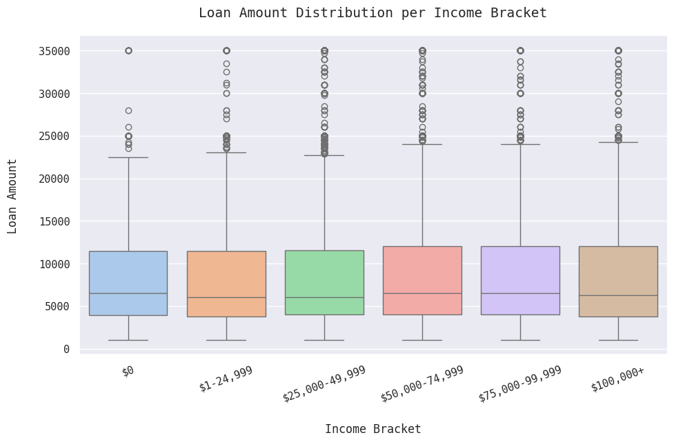

```python
plt.figure(figsize=(11,6))
sns.boxplot(data=anova_df, x='IncomeRange', y='LoanOriginalAmount', palette='pastel')
plt.xticks(rotation=20)
plt.title('Loan Amount Distribution per Income Bracket')
plt.xlabel('Income Bracket', labelpad=20)
plt.ylabel('Loan Amount', labelpad=20)
plt.show()
```

These distributions are positively skewed and muli-modial which indicates ANOVA testing can't be used - from the bottom side median and top side outliers then shape & spread of histrograms.

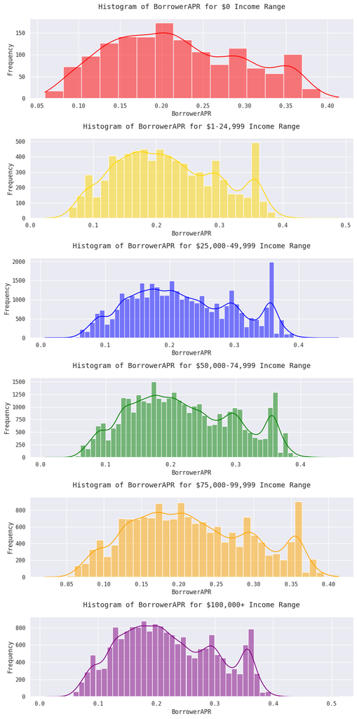

```python
# initializing bins
bins_0 = np.histogram_bin_edges(test_4_0, bins='auto')
bins_1 = np.histogram_bin_edges(test_4_1, bins='auto')
bins_25 = np.histogram_bin_edges(test_4_25, bins='auto')
bins_50 = np.histogram_bin_edges(test_4_50, bins='auto')
bins_75 = np.histogram_bin_edges(test_4_75, bins='auto')
bins_100 = np.histogram_bin_edges(test_4_100, bins='auto')

fig, axs = plt.subplots(6, 1, figsize=(10, 20))

# Plot histograms for Test 4
sns.histplot(test_4_0, color='red', alpha=0.5, bins=bins_0, kde=True, ax=axs[0])
axs[0].set_title('Histogram of BorrowerAPR for $0 Income Range')
axs[0].set_xlabel('BorrowerAPR')
axs[0].set_ylabel('Frequency')

sns.histplot(test_4_1, color='gold', alpha=0.5, bins=bins_1, kde=True, ax=axs[1])
axs[1].set_title('Histogram of BorrowerAPR for $1-24,999 Income Range')
axs[1].set_xlabel('BorrowerAPR')
axs[1].set_ylabel('Frequency')

sns.histplot(test_4_25, color='blue', alpha=0.5, bins=bins_25, kde=True, ax=axs[2])
axs[2].set_title('Histogram of BorrowerAPR for $25,000-49,999 Income Range')
axs[2].set_xlabel('BorrowerAPR')
axs[2].set_ylabel('Frequency')

sns.histplot(test_4_50, color='green', alpha=0.5, bins=bins_50, kde=True, ax=axs[3])
axs[3].set_title('Histogram of BorrowerAPR for $50,000-74,999 Income Range')
axs[3].set_xlabel('BorrowerAPR')
axs[3].set_ylabel('Frequency')

sns.histplot(test_4_75, color='orange', alpha=0.5, bins=bins_75, kde=True, ax=axs[4])
axs[4].set_title('Histogram of BorrowerAPR for $75,000-99,999 Income Range')
axs[4].set_xlabel('BorrowerAPR')
axs[4].set_ylabel('Frequency')

sns.histplot(test_4_100, color='purple', alpha=0.5, bins=bins_100, kde=True, ax=axs[5])
axs[5].set_title('Histogram of BorrowerAPR for $100,000+ Income Range')
axs[5].set_xlabel('BorrowerAPR')
axs[5].set_ylabel('Frequency')

plt.tight_layout()
plt.show()
```

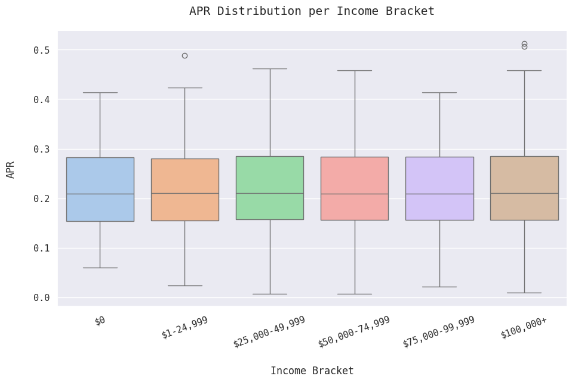

```python
plt.figure(figsize=(11,6))
sns.boxplot(data=anova_df, x='IncomeRange', y='BorrowerAPR', palette='pastel')
plt.xticks(rotation=20)
plt.title('APR Distribution per Income Bracket')
plt.xlabel('Income Bracket', labelpad=20)
plt.ylabel('APR', labelpad=20)
plt.show()
```

These distributions are approximately normal, deviations are the .35 peaks, slight negative-skew, and the too gradual of a decline down the curve. Given my large n size of 1450, ANOVA could be robust enough against this degree of non-normality. Shapiro Wilk test will be performed to confirm.

### Creating Test 3 & 4 Samples for Statistical Modelling

```python
# Since IncomeRange isn't depdenent on Amount/APR, tests 3 and 4 have groups of equal size
print('Sizes (N) of Loan Amount/APR by Income Range')
print('$0:', len(test_3_0))
print('$1-24,999:', len(test_3_1))
print('$25,000-49,999:', len(test_3_25))
print('$50,000-74,999:', len(test_3_50))
print('$75,000-99,999:', len(test_3_75))
print('$100,000+:', len(test_3_100), '\n')
```

```
Sizes (N) of Loan Amount/APR by Income Range
$0: 1459
$1-24,999: 7511
$25,000-49,999: 35212
$50,000-74,999: 33466
$75,000-99,999: 16910
$100,000+: 18508
```

```python
# Original groups are being filtered to eliminate outliers
test3_groups = [test_3_0, test_3_1, test_3_25, test_3_50, test_3_75, test_3_100]
test3_groups_filtered = [list(filter(lambda x: x <= 18000, group)) for group in test3_groups]
test3_group_0, test3_group_1, test3_group_25, test3_group_50, test3_group_75, test3_group_100 = test3_groups_filtered
```

```python
# Test 3 samples
np.random.seed(14)
test3_sample_0 = np.random.choice(test3_group_0, size=1455)
test3_sample_1 = np.random.choice(test3_group_1, size=1455)
test3_sample_25 = np.random.choice(test3_group_25, size=1455)
test3_sample_50 = np.random.choice(test3_group_50, size=1455)
test3_sample_75 = np.random.choice(test3_group_75, size=1455)
test3_sample_100 = np.random.choice(test3_group_100, size=1455)
```

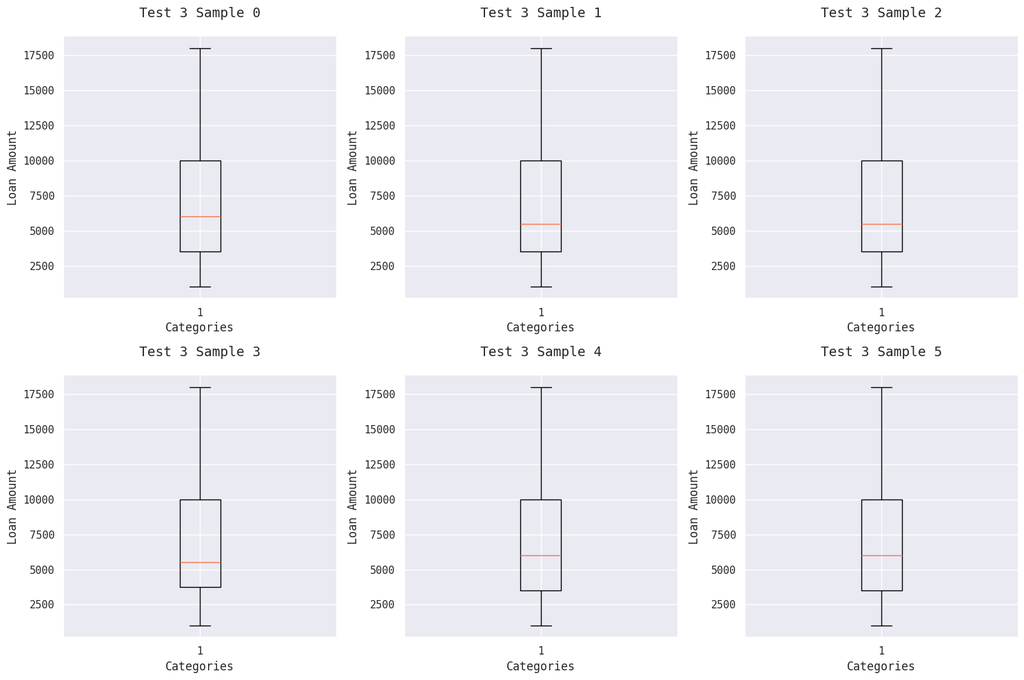

```python
# Box plots for estimating variance and no outliers validation
test3_samples = [test3_sample_0, test3_sample_1, test3_sample_25, test3_sample_50, test3_sample_75, test3_sample_100]

fig, axs = plt.subplots(2, 3, figsize=(15, 10))

# Flatten the axs array to iterate easily
axs = axs.flatten()

for i, (sample, ax) in enumerate(zip(test3_samples, axs)):
    ax.boxplot(sample)
    ax.set_title(f'Test 3 Sample {i}')
    ax.set_ylabel('Loan Amount')
    ax.set_xlabel('Categories')

plt.tight_layout()
plt.show()
```

```python
# Test 4 samples
np.random.seed(7)
test4_sample_0 = np.random.choice(test_4_0, size=1455)
test4_sample_1 = np.random.choice(test_4_1, size=1455)
test4_sample_25 = np.random.choice(test_4_25, size=1455)
test4_sample_50 = np.random.choice(test_4_50, size=1455)
test4_sample_75 = np.random.choice(test_4_75, size=1455)
test4_sample_100 = np.random.choice(test_4_100, size=1455)
```

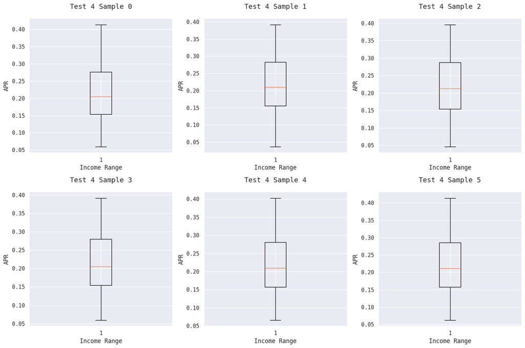

```python
# Box plots for estimating variance and no outliers validation
test4_samples = [test4_sample_0, test4_sample_1, test4_sample_25, test4_sample_50, test4_sample_75, test4_sample_100]

fig, axs = plt.subplots(2, 3, figsize=(15, 10))

# Flatten the axs array to iterate over it easily
axs = axs.flatten()

for i, (sample, ax) in enumerate(zip(test4_samples, axs)):
    ax.boxplot(sample)
    ax.set_title(f'Test 4 Sample {i}')
    ax.set_ylabel('APR')
    ax.set_xlabel('Income Range')

plt.tight_layout()
plt.show()
```

This is confirmation of homoscedastic groups. My Kurksal-Willis for test 3 will have increased accuracy and reliability. Validates the final condition to attempt an ANOVA in test 4.

### Test 3 - Kurksal Wallis

```python
statistic, p_value = kruskal(test3_sample_0, test3_sample_1, test3_sample_25, test3_sample_50, test3_sample_75, test3_sample_100)
print("statistic:", round(statistic, 3))
print("P-value:", round(p_value, 2))

if p_value <= alpha:
    print("Reject the null hypothesis. There is a significant difference between at least two group medians.")
else:
    print("Fail to reject the null hypothesis. There is no significant difference between group medians.")
```

```
statistic: 1.56
P-value: 0.91
Fail to reject the null hypothesis. There is no significant difference between group medians.
```

### Results

The results indicate further testing with a Post Hoc isn't required since there is no signficance detected. This test clarifies that Income Range isn't considered in the decision-making at Prosper when approving a loan amount for a new applicant.

```python
# ANOVA
f_statistic, p_value = f_oneway(test4_sample_0, test4_sample_1, test4_sample_25, test4_sample_50, test4_sample_75, test4_sample_100)
print("statistic:", round(f_statistic, 3))
print(round(p_value, 2))

if p_value <= alpha:
    print("Reject the null hypothesis. There is a significant difference between at least two group means.")
else:
    print("Fail to reject the null hypothesis. There is no significant difference between group means.")
```

```
statistic: 1.239
0.29
Fail to reject the null hypothesis. There is no significant difference between group means.
```

## Research Question 2:

Can loan outcomes be predicted for new customers who apply?

### Table preparation

```python
mega_df.drop('Unnamed: 0', axis=1, inplace=True)
```

```python
mega_df.loc[:, 'CreditScore'] = round((mega_df.loc[:, 'CreditScoreRangeUpper']+mega_df.loc[:, 'CreditScoreRangeLower'])/2, 0)
```

These are many inputs compared to models in other research studies. To reduce noise, I'll be joining the 2 Credit Score attributes into a single attribute using a derived variable technique. Applicants submit their request with a specified amount and Prosper designates an APR and Rate during this process, which means that these conditions can be used for the model since it's accessible before approval. Secondly, non-relevant features drop: Occupation, PK, LoanNumber, EmploymentStatusDuration, and Term (ruins density with little reward).

```python
mega_df.drop(['CreditScoreRangeUpper', 'CreditScoreRangeLower', 'Occupation', 'PK', 'Term', 'LoanNumber',
              'EmploymentStatusDuration'], axis=1, inplace=True)
```

```python
# Removing the mean imputes made in part 1. I don't want these imputes affecting my model and am opting for a sample
# instead of population with imputes
# comparing these sizes to the original nulls of customer_df to drop from mega_df
print(mega_df.query('DebtToIncomeRatio == 0.2760324776755837').shape)
print(mega_df.query('TotalTrades == 23.221517787759897').shape)
print(mega_df.query('ProsperScore == 5.952870853278084').shape)
```

```
(8472, 19)
(7544, 19)
(29084, 19)
```

```python
# dropping from mega_df
condition1 = mega_df['DebtToIncomeRatio'] == 0.2760324776755837
condition2 = mega_df['TotalTrades'] == 23.221517787759897
condition3 = mega_df['ProsperScore'] == 5.952870853278084

filtered_df = mega_df.query('~(DebtToIncomeRatio == 0.2760324776755837 | TotalTrades == 23.221517787759897 | ProsperScore == 5.952870853278084)')


print(filtered_df.shape)
```

```
(76768, 19)
```

Checking densities and unobvious null values (like 'N/A') in categorical features. Also dropping records with unusable LoanStatus values such as current or cancelled - which will be done first since it can affect the other 2 edits mentioned.

```python
categories_to_drop = ['Past Due (1-15 days)', 'Past Due (31-60 days)', 'Past Due (61-90 days)',
                      'Past Due (91-120 days)', 'Past Due (16-30 days)', 'FinalPaymentInProgress',
                      'Past Due (>120 days)', 'Cancelled', 'Current']

filtered_df = filtered_df[~filtered_df['LoanStatus'].isin(categories_to_drop)]

# verify the rows are dropped
print(filtered_df.shape)
```

```
(37383, 19)
```

```python
# taking averages across the classes explored in this research question for export tables
credit_rating = round(anova_df[['LoanOriginalAmount', 'BorrowerAPR', 'CreditScore']].groupby('CreditScore').mean(), 2)
income_range = round(anova_df[['LoanOriginalAmount', 'BorrowerAPR', 'IncomeRange']].groupby('IncomeRange').mean(), 2)

# for part I
prosper_score = round(filtered_df[['LoanOriginalAmount', 'BorrowerAPR', 'CurrentDelinquencies', 'AmountDelinquent',
                                   'OpenCreditLines', 'CreditScore', 'ProsperScore', 'DebtToIncomeRatio',
                                   'BankcardUtilization', 'Recommendations']].groupby('ProsperScore').mean(), 2)
```

```python
# To improve model performance, defaulted & charged off values for Loan Status are merged into a single default value
loanstatus_mask = filtered_df['LoanStatus'] == 'Chargedoff'
filtered_df.loc[loanstatus_mask, 'LoanStatus'] = 'Defaulted'
```

```python
# Used for identifying a scaling option
filtered_df.describe()
```

|  | BorrowerAPR | BorrowerRate | ListingCategory (numeric) | LoanOriginalAmount | OpenCreditLines | TotalCreditLinespast7years | TotalInquiries | CurrentDelinquencies | AmountDelinquent | BankcardUtilization | ProsperScore | TotalTrades | DebtToIncomeRatio | IncomeVerifiable | Recommendations | CreditScore |
| --- | --- | --- | --- | --- | --- | --- | --- | --- | --- | --- | --- | --- | --- | --- | --- | --- |
| count | 37383.000 | 37383.000 | 37383.000 | 37383.000 | 37383.000 | 37383.000 | 37383.000 | 37383.000 | 37383.000 | 37383.000 | 37383.000 | 37383.000 | 37383.000 | 37383.00 | 37383.000 | 37383.000 |
| mean | 0.222 | 0.200 | 2.407 | 6258.513 | 8.474 | 25.395 | 7.117 | 0.889 | 1041.338 | 0.535 | 6.054 | 24.226 | 0.260 | 1.00 | 0.016 | 682.173 |
| std | 0.088 | 0.081 | 3.404 | 5214.834 | 4.640 | 14.165 | 8.221 | 2.498 | 5907.831 | 0.326 | 2.356 | 11.686 | 0.329 | 0.02 | 0.153 | 81.341 |
| min | 0.007 | 0.000 | 0.000 | 1000.000 | 0.000 | 2.000 | 0.000 | 0.000 | 0.000 | 0.000 | 1.000 | 1.000 | 0.000 | 0.00 | 0.000 | 10.000 |
| 25% | 0.150 | 0.135 | 0.000 | 2600.000 | 5.000 | 15.000 | 2.000 | 0.000 | 0.000 | 0.270 | 4.000 | 16.000 | 0.150 | 1.00 | 0.000 | 650.000 |
| 50% | 0.214 | 0.194 | 1.000 | 4500.000 | 9.000 | 24.000 | 5.000 | 0.000 | 0.000 | 0.561 | 6.000 | 23.000 | 0.220 | 1.00 | 0.000 | 690.000 |
| 75% | 0.295 | 0.270 | 3.000 | 8000.000 | 10.000 | 34.000 | 9.000 | 1.000 | 475.000 | 0.810 | 8.000 | 31.000 | 0.320 | 1.00 | 0.000 | 730.000 |
| max | 0.512 | 0.497 | 20.000 | 35000.000 | 48.000 | 129.000 | 379.000 | 64.000 | 327677.000 | 5.830 | 11.000 | 122.000 | 10.010 | 1.00 | 9.000 | 890.000 |

```python
# Credit Score has a high standard deviation. This is done to reduce noise and bolster signal in models
filtered_df = credit_rates(filtered_df)
filtered_df['CreditScore'] = filtered_df['CreditScore'].astype(credit_ratings)
```

```python
categoricals = ['LoanStatus', 'IncomeRange', 'ListingCategory', 'ProsperScore', 'EmploymentStatus', 'IncomeVerifiable',
                'Recommendations', 'CreditScore']
def print_value_counts(df, categorical_features):
    for feature in categorical_features:
        print(f"Value counts for {feature}:")
        print(df[feature].value_counts())
        print("="*50)  # Adding separator for better readability

filtered_df.rename(columns={'ListingCategory (numeric)':'ListingCategory'}, inplace=True)
print_value_counts(filtered_df, categoricals)
```

```
Value counts for LoanStatus:
LoanStatus
Completed    25875
Defaulted    11508
Name: count, dtype: int64
==================================================
Value counts for IncomeRange:
IncomeRange
$50,000-74,999    11621
$25,000-49,999    10587
$100,000+          6716
$75,000-99,999     6607
$1-24,999          1852
Name: count, dtype: int64
==================================================
Value counts for ListingCategory:
ListingCategory
1     12138
0     11508
7      4107
3      2897
2      2197
4      1626
6      1028
5       493
13      403
15      242
19      147
18      142
14      127
20      121
16       55
11       42
10       35
8        28
9        23
12       13
17       11
Name: count, dtype: int64
==================================================
```

[output cut: 35 more lines]

```
2.0       64
3.0        8
5.0        2
9.0        1
Name: count, dtype: int64
==================================================
Value counts for CreditScore:
CreditScore
Good           15726
Fair            9521
Very Good       6471
Poor            3753
Exceptional     1912
Name: count, dtype: int64
==================================================
```

```python
# from the mega_table record drops
filtered_df.reset_index(inplace=True, drop=True)
```

```python
# Sampling 80% of my model for training & evaluation, 20% for test
training_df = filtered_df.sample(frac=.8, replace=False)
```

```python
# Checking densities of each category
print_value_counts(training_df, categoricals)
```

```
Value counts for LoanStatus:
LoanStatus
Completed    20620
Defaulted     9286
Name: count, dtype: int64
==================================================
Value counts for IncomeRange:
IncomeRange
$50,000-74,999    9263
$25,000-49,999    8477
$100,000+         5393
$75,000-99,999    5313
$1-24,999         1460
Name: count, dtype: int64
==================================================
Value counts for ListingCategory:
ListingCategory
1     9683
0     9163
7     3275
3     2364
2     1768
4     1290
6      828
5      401
13     326
15     196
18     121
19     118
14     100
20      99
16      45
11      35
10      31
8       24
9       19
12      11
17       9
Name: count, dtype: int64
==================================================
```

[output cut: 35 more lines]

```
2.0       51
3.0        5
9.0        1
5.0        1
Name: count, dtype: int64
==================================================
Value counts for CreditScore:
CreditScore
Good           12576
Fair            7603
Very Good       5187
Poor            3024
Exceptional     1516
Name: count, dtype: int64
==================================================
```

```python
# removing sample records from filtered_table/training_df to instantiate test table
train_index = training_df.index
train_mask = filtered_df.index.isin(train_index)
filtered_df = filtered_df[~train_mask]
print('Training sample:', training_df.shape)
```

```
Training sample: (29906, 19)
```

```python
test_df = filtered_df.copy()
print('Test 1 sample:', test_df.shape)
```

```
Test 1 sample: (7477, 19)
```

```python
training_df.info()
```

```
<class 'pandas.core.frame.DataFrame'>
Index: 29906 entries, 33380 to 3734
Data columns (total 19 columns):
 #   Column                      Non-Null Count  Dtype
---  ------                      --------------  -----
 0   LoanStatus                  29906 non-null  object
 1   BorrowerAPR                 29906 non-null  float64
 2   BorrowerRate                29906 non-null  float64
 3   ListingCategory             29906 non-null  int64
 4   LoanOriginalAmount          29906 non-null  int64
 5   OpenCreditLines             29906 non-null  float64
 6   TotalCreditLinespast7years  29906 non-null  float64
 7   TotalInquiries              29906 non-null  float64
 8   CurrentDelinquencies        29906 non-null  float64
 9   AmountDelinquent            29906 non-null  float64
 10  BankcardUtilization         29906 non-null  float64
 11  ProsperScore                29906 non-null  float64
 12  EmploymentStatus            29906 non-null  object
 13  TotalTrades                 29906 non-null  float64
 14  DebtToIncomeRatio           29906 non-null  float64
 15  IncomeRange                 29906 non-null  object
 16  IncomeVerifiable            29906 non-null  float64
 17  Recommendations             29906 non-null  float64
 18  CreditScore                 29906 non-null  category
dtypes: category(1), float64(13), int64(2), object(3)
memory usage: 4.4+ MB
```

### Standardizing non-categorical quantitative attributes

RobustScaler is used since there are extreme outliers contained in these datasets. Function auto-scales for each feature. Use the above .describe()

```python
numeric_columns = ['BorrowerAPR', 'BorrowerRate', 'LoanOriginalAmount', 'OpenCreditLines', 'TotalCreditLinespast7years',
                   'TotalInquiries', 'CurrentDelinquencies', 'AmountDelinquent', 'BankcardUtilization', 'TotalTrades',
                   'DebtToIncomeRatio', 'Recommendations', 'ProsperScore']

def standardize(df):
    RS = RobustScaler()
    scale = RS.fit_transform(df[numeric_columns])
    scaled_df = scale.rename(columns=lambda x: x.replace('x0_', ''))

    # Concat the input df and scaled values
    final_df = pd.concat([df.drop(columns=numeric_columns).reset_index(drop=True), scaled_df.reset_index(drop=True)], axis=1)
    return final_df

training_df = standardize(training_df)
test_df = standardize(test_df)
```

### Encoding qualitative attributes

```python
def OE_encode(df, col):
    OE = OrdinalEncoder(dtype=int)
    income_labels = np.array(df[col].values)
    income_labels_reshaped = income_labels.reshape(-1, 1)
    income_transform = OE.fit_transform(income_labels_reshaped)
    encoded_income_df = np.array(income_transform.values)
    return encoded_income_df

training_income = OE_encode(training_df, 'IncomeRange')
test_income = OE_encode(test_df, 'IncomeRange')
test_credit = OE_encode(test_df, 'CreditScore')
training_credit = OE_encode(training_df, 'CreditScore')

# validating ordinals
print(training_income)
print(training_df.IncomeRange)

print(training_credit)
print(training_df.CreditScore)
```

```
[[2]
 [2]
 [2]
 ...
 [0]
 [3]
 [2]]
0        $25,000-49,999
1        $25,000-49,999
2        $25,000-49,999
3        $25,000-49,999
4        $50,000-74,999
              ...
29901    $25,000-49,999
29902         $100,000+
29903         $1-24,999
29904    $50,000-74,999
29905    $25,000-49,999
Name: IncomeRange, Length: 29906, dtype: object
[[1]
 [4]
 [1]
 ...
 [4]
 [4]
 [2]]
0               Fair
1          Very Good
2               Fair
3        Exceptional
4          Very Good
            ...
29901           Fair
29902    Exceptional
29903      Very Good
29904      Very Good
29905           Good
Name: CreditScore, Length: 29906, dtype: category
Categories (5, object): ['Poor' < 'Fair' < 'Good' < 'Very Good' < 'Exceptional']
```

```python
def col_replacer(df, col, encode):
    df2 = df.copy()
    df2[col] = encode
    return df2

# entering IncomeRange encode into datasets
training_df = col_replacer(training_df, 'IncomeRange', training_income)
test_df = col_replacer(test_df, 'IncomeRange', test_income)
training_df = col_replacer(training_df, 'CreditScore', training_credit)
test_df = col_replacer(test_df, 'CreditScore', test_credit)
```

```python
def OH_encode(df, column_name):
    encoder = OneHotEncoder(sparse=False, dtype=int)
    data_to_encode = np.array(df[column_name].values.reshape(-1, 1))
    encoded_df = encoder.fit_transform(data_to_encode)
    encoded_df = encoded_df.rename(columns=lambda x: x.replace('x0_', ''))

    # Combining original and OH matrix. Dropped the input feature and reset_index for concat
    if column_name != 'LoanStatus':
        df = pd.concat([df.drop(column_name, axis=1).reset_index(drop=True), encoded_df], axis=1)
    else:
        df = encoded_df.copy()
    return df

test_df = OH_encode(test_df, 'EmploymentStatus')
training_df = OH_encode(training_df, 'EmploymentStatus')
```

```python
test_df.columns
```

```
Index(['LoanStatus', 'ListingCategory', 'IncomeRange', 'IncomeVerifiable',
       'CreditScore', 'BorrowerAPR', 'BorrowerRate', 'LoanOriginalAmount',
       'OpenCreditLines', 'TotalCreditLinespast7years', 'TotalInquiries',
       'CurrentDelinquencies', 'AmountDelinquent', 'BankcardUtilization',
       'TotalTrades', 'DebtToIncomeRatio', 'Recommendations', 'ProsperScore',
       'Employed', 'Full-time', 'Other', 'Part-time', 'Retired',
       'Self-employed'],
      dtype='object')
```

```python
training_df.columns
```

```
Index(['LoanStatus', 'ListingCategory', 'IncomeRange', 'IncomeVerifiable',
       'CreditScore', 'BorrowerAPR', 'BorrowerRate', 'LoanOriginalAmount',
       'OpenCreditLines', 'TotalCreditLinespast7years', 'TotalInquiries',
       'CurrentDelinquencies', 'AmountDelinquent', 'BankcardUtilization',
       'TotalTrades', 'DebtToIncomeRatio', 'Recommendations', 'ProsperScore',
       'Employed', 'Full-time', 'Other', 'Part-time', 'Retired',
       'Self-employed'],
      dtype='object')
```

```python
y_df = pd.DataFrame()
y_df['LoanStatus'] = test_df['LoanStatus'].copy()
print('Test df y-values:', y_df.shape)
print('Test df:', test_df.shape)

# no Loan Status feature in the test set
test_df.drop('LoanStatus', axis=1, inplace=True)
```

```
Test df y-values: (7477, 1)
Test df: (7477, 24)
```

```python
y_df.head(2)
```

|  | LoanStatus |
| --- | --- |
| 0 | Completed |
| 1 | Defaulted |

```python
def label_encode(df, column_name):
    label_encoder = LabelEncoder()
    column_data = np.array(df[column_name].values)

    if len(column_data.shape) == 1:
        column_data = column_data.reshape(-1, 1)

    encoded_column = label_encoder.fit_transform(column_data)
    final_df = pd.DataFrame()
    final_df['LoanStatus'] = encoded_column
    return final_df, label_encoder

y, LE = label_encode(training_df, 'LoanStatus')
y.head(2)
```

|  | LoanStatus |
| --- | --- |
| 0 | 0 |
| 1 | 0 |

```python
# removing y from x training set
training_df.drop('LoanStatus', axis=1, inplace=True)
training_df.head(2)
```

|  | ListingCategory | IncomeRange | IncomeVerifiable | CreditScore | BorrowerAPR | BorrowerRate | LoanOriginalAmount | OpenCreditLines | TotalCreditLinespast7years | TotalInquiries | ... | TotalTrades | DebtToIncomeRatio | Recommendations | ProsperScore | Employed | Full-time | Other | Part-time | Retired | Self-employed |
| --- | --- | --- | --- | --- | --- | --- | --- | --- | --- | --- | --- | --- | --- | --- | --- | --- | --- | --- | --- | --- | --- |
| 0 | 1 | 2 | 1.0 | 1 | 1.189 | 1.156 | -0.324 | -1.2 | -1.000 | -0.714 | ... | 1.800 | 0.412 | 0.0 | -0.25 | 1 | 0 | 0 | 0 | 0 | 0 |
| 1 | 1 | 2 | 1.0 | 4 | -0.458 | -0.445 | 1.302 | -0.4 | 0.474 | -0.714 | ... | -0.067 | -1.118 | 0.0 | -0.50 | 1 | 0 | 0 | 0 | 0 | 0 |

2 rows × 23 columns

```python
# comparing standard deviations (S) to identify higher risk columns
training_df[['CurrentDelinquencies', 'AmountDelinquent', 'BankcardUtilization', 'OpenCreditLines',
       'TotalCreditLinespast7years', 'LoanOriginalAmount', 'TotalTrades', 'DebtToIncomeRatio',
             'Recommendations', 'TotalInquiries', 'ProsperScore', 'ListingCategory', 'BorrowerRate',
            'BorrowerAPR']].describe()
```

|  | CurrentDelinquencies | AmountDelinquent | BankcardUtilization | OpenCreditLines | TotalCreditLinespast7years | LoanOriginalAmount | TotalTrades | DebtToIncomeRatio | Recommendations | TotalInquiries | ProsperScore | ListingCategory | BorrowerRate | BorrowerAPR |
| --- | --- | --- | --- | --- | --- | --- | --- | --- | --- | --- | --- | --- | --- | --- |
| count | 29906.000 | 29906.000 | 29906.000 | 29906.000 | 29906.000 | 29906.000 | 29906.000 | 29906.000 | 29906.000 | 29906.000 | 29906.000 | 29906.000 | 29906.000 | 29906.000 |
| mean | 0.889 | 2.212 | -0.046 | -0.104 | 0.076 | 0.325 | 0.082 | 0.238 | 0.016 | 0.308 | 0.014 | 2.421 | 0.049 | 0.056 |
| std | 2.515 | 12.463 | 0.603 | 0.931 | 0.748 | 0.968 | 0.780 | 2.033 | 0.153 | 1.203 | 0.589 | 3.421 | 0.603 | 0.607 |
| min | 0.000 | 0.000 | -1.039 | -1.800 | -1.158 | -0.648 | -1.467 | -1.294 | 0.000 | -0.714 | -1.250 | 0.000 | -1.438 | -1.429 |
| 25% | 0.000 | 0.000 | -0.539 | -0.800 | -0.474 | -0.352 | -0.467 | -0.412 | 0.000 | -0.429 | -0.500 | 0.000 | -0.437 | -0.444 |
| 50% | 0.000 | 0.000 | 0.000 | 0.000 | 0.000 | 0.000 | 0.000 | 0.000 | 0.000 | 0.000 | 0.000 | 1.000 | 0.000 | 0.000 |
| 75% | 1.000 | 1.000 | 0.461 | 0.200 | 0.526 | 0.648 | 0.533 | 0.588 | 0.000 | 0.571 | 0.500 | 3.000 | 0.563 | 0.556 |
| max | 64.000 | 688.759 | 9.757 | 7.800 | 5.526 | 5.648 | 6.600 | 57.588 | 9.000 | 53.429 | 1.250 | 20.000 | 1.898 | 1.703 |

```python
# Different test versions (X, X2, test_df, test2) for feature selection
X = training_df.copy()

# Risky quantitative features (high S) are dropped. Noise & complexity is further reduced by selecting one
# column to represent a statistic. Ex: instead of TotalCreditLines and OpenCreditLines, the latter is chosen for it's higher relevancy.
# some are dropepd from irrelevenacy even though they have lower S. See BankCardUtilization or TotalTrades
# Listing category snipped since half are 'Not Available' values
X2 = training_df.drop(['BorrowerAPR', 'TotalInquiries', 'BankcardUtilization', 'TotalTrades',
                       'DebtToIncomeRatio', 'ProsperScore', 'TotalCreditLinespast7years', 'AmountDelinquent',
                      'CurrentDelinquencies', 'ListingCategory'], axis=1).copy()
test2 = test_df.drop(['BorrowerAPR', 'TotalInquiries', 'BankcardUtilization', 'TotalTrades',
                       'DebtToIncomeRatio', 'ProsperScore', 'TotalCreditLinespast7years', 'AmountDelinquent',
                      'CurrentDelinquencies', 'ListingCategory'], axis=1).copy()

# Aligning row counts for x and y
print(training_df.shape)
print(y.shape)
```

```
(29906, 23)
(29906, 1)
```

```python
X2.columns
```

```
Index(['IncomeRange', 'IncomeVerifiable', 'CreditScore', 'BorrowerRate',
       'LoanOriginalAmount', 'OpenCreditLines', 'Recommendations', 'Employed',
       'Full-time', 'Other', 'Part-time', 'Retired', 'Self-employed'],
      dtype='object')
```

## Model Evaluation

Preparation is completed. Various models are trained then tested for effectiveness - measured by accuracy, recall, precision, and F1-score. "y_df" is correct y-values for the testing set. Test set is "test_df" & "test2". Training set split into 2 types, "X" and "y". Stratify=y and average=weighted to accomadate the class imbalance between Completed (5000) and Defaulted (2500). Turning either off resulted in model scoring that gave exact values for all metrics and even some models.

If tuning to find the perfect parameters, use a top-down approach. Start with big intervals and when the bigger interval is found, zoom in and inspect units within that interval. Max_depth= controls how many levels of splits the tree can have from the root node to the leaf nodes - deeper trees can overfit. Random Forest n_estimator= represents the number of base estimators (decision trees) to be aggregated in the ensemble. XGBoost, LightGBM, ADABoost n_estimator= determines the number of boosting stages or iterations. Increases the complexity of the model which can lead to overfitting.

```python
X_train, X_valid, y_train, y_valid = train_test_split(X2, y, train_size=.7, stratify=y, test_size=.3)

# the true cross prediction answers
true_preds = LE.inverse_transform(y_valid)
true_eval_c = [item for item in true_preds].count('Completed')
true_eval_d = [item for item in true_preds].count('Defaulted')
```

### Random Forest

```python
rf_model = RandomForestClassifier(n_estimators=90, max_depth=None, min_samples_split=2, min_samples_leaf=1)

# cross eval
stratified_kfold = StratifiedKFold(n_splits = 5)
cv_scores_rf = cross_val_score(rf_model, X_train, y_train, cv=stratified_kfold)
predicted = cross_val_predict(rf_model, X_valid, y_valid, cv=stratified_kfold)
print("Cross Validation Scores: ", np.round(cv_scores_rf, 2))

rf_model.fit(X_train, y_train)
preds_valid = rf_model.predict(X_valid)
```

```
Cross Validation Scores:  [0.68 0.67 0.68 0.67 0.68]
```

```python
avg_cv_rf = np.round(cv_scores_rf.mean(), 2)
print("Average Cross Accuracy: ", avg_cv_rf)

accuracy_rf = round(accuracy_score(y_valid, preds_valid), 2)
print("Random Forest Accuracy:", accuracy_rf)

precision_rf = round(precision_score(y_valid, preds_valid, average='weighted'), 2)
print("Random Forest Precision:", precision_rf)

recall_rf = round(recall_score(y_valid, preds_valid, average='weighted'), 2)
print("Random Forest Recall:", recall_rf)

f1_rf = round(f1_score(y_valid, preds_valid, average='weighted'), 2)
print("Random Forest F1-Score:", f1_rf)
```

```
Average Cross Accuracy:  0.68
Random Forest Accuracy: 0.68
Random Forest Precision: 0.66
Random Forest Recall: 0.68
Random Forest F1-Score: 0.66
```

```python
# cross eval predictions
cross_preds_rf = LE.inverse_transform(predicted)
cross_c_rf = [item for item in cross_preds_rf].count('Completed')
cross_d_rf = [item for item in cross_preds_rf].count('Defaulted')

# model predictions
eval_preds_rf = LE.inverse_transform(preds_valid)
eval_c_rf = [item for item in eval_preds_rf].count('Completed')
eval_d_rf = [item for item in eval_preds_rf].count('Defaulted')

print('cross results:', [cross_c_rf, cross_d_rf])
print('evaluation results:', [eval_c_rf, eval_d_rf])
print('true answers:', [true_eval_c, true_eval_d])
```

```
cross results: [7211, 1761]
evaluation results: [7086, 1886]
true answers: [6186, 2786]
```

### Decision Tree

```python
# criterion= gini or entropy
dt_model = DecisionTreeClassifier(criterion='gini', max_depth=None, min_samples_split=2, min_samples_leaf=1)

# cross eval
cv_scores_dt = cross_val_score(dt_model, X_train, y_train, cv=stratified_kfold)
predicted = cross_val_predict(dt_model, X_valid, y_valid, cv=stratified_kfold)
print("Cross Validation Scores: ", np.round(cv_scores_dt, 2))

dt_model.fit(X_train, y_train)
preds_valid = dt_model.predict(X_valid)
```

```
Cross Validation Scores:  [0.61 0.61 0.63 0.61 0.62]
```

```python
avg_cv_dt = np.round(cv_scores_dt.mean(), 2)
print("Average Cross Accuracy: ", avg_cv_dt)

accuracy_dt = round(accuracy_score(y_valid, preds_valid), 2)
print("Decision Tree Accuracy:", accuracy_dt)

precision_dt = round(precision_score(y_valid, preds_valid, average='weighted'), 2)
print("Decision Tree Precision:", precision_dt)

recall_dt = round(recall_score(y_valid, preds_valid, average='weighted'), 2)
print("Decision Tree Recall:", recall_dt)

f1_dt = round(f1_score(y_valid, preds_valid, average='weighted'), 2)
print("Decision Tree F1-Score:", f1_dt)
```

```
Average Cross Accuracy:  0.62
Decision Tree Accuracy: 0.61
Decision Tree Precision: 0.62
Decision Tree Recall: 0.61
Decision Tree F1-Score: 0.62
```

```python
# cross eval predictions
cross_preds_dt = LE.inverse_transform(predicted)
cross_c_dt = [item for item in cross_preds_dt].count('Completed')
cross_d_dt = [item for item in cross_preds_dt].count('Defaulted')

# model predictions
eval_preds_dt = LE.inverse_transform(preds_valid)
eval_c_dt = [item for item in eval_preds_dt].count('Completed')
eval_d_dt = [item for item in eval_preds_dt].count('Defaulted')

print('cross results:', [cross_c_dt, cross_d_dt])
print('evaluation results:', [eval_c_dt, eval_d_dt])
print('true answers:', [true_eval_c, true_eval_d])
```

```
cross results: [6122, 2850]
evaluation results: [6075, 2897]
true answers: [6186, 2786]
```

### Logistic Regression

```python
# L1 regularization since L2 was too impactful. lbfgs = l2. liblinear = l1. saga = elasticnet (include l1_ratio=)
# lower C= is harsher regulariztion to lower overfitting
lr_classifier = LogisticRegression(multi_class='auto', solver='liblinear', penalty='l1', C=.5,
                                   class_weight='balanced')
lr_model = MultiOutputClassifier(lr_classifier)

# cross eval
cv_scores_lr = cross_val_score(lr_model, X_train, y_train, cv=stratified_kfold)
predicted = cross_val_predict(lr_model, X_valid, y_valid, cv=stratified_kfold)
print("Cross Validation Scores: ", np.round(cv_scores_lr, 2))

lr_model.fit(X_train, y_train)
preds_valid = lr_model.predict(X_valid)
```

```
Cross Validation Scores:  [0.62 0.62 0.62 0.61 0.62]
```

```python
avg_cv_lr = np.round(cv_scores_lr.mean(), 2)
print("Average Cross Accuracy: ", avg_cv_lr)

accuracy_lr = round(accuracy_score(y_valid, preds_valid), 2)
print("Logistic Regression Accuracy:", accuracy_lr)

precision_lr = round(precision_score(y_valid, preds_valid, average='weighted'), 2)
print("Logistic Regression Precision:", precision_lr)

recall_lr = round(recall_score(y_valid, preds_valid, average='weighted'), 2)
print("Logistic Regression Recall:", recall_lr)

f1_lr = round(f1_score(y_valid, preds_valid, average='weighted'), 2)
print("Logistic Regression F1-Score:", f1_lr)
```

```
Average Cross Accuracy:  0.62
Logistic Regression Accuracy: 0.63
Logistic Regression Precision: 0.68
Logistic Regression Recall: 0.63
Logistic Regression F1-Score: 0.64
```

```python
# cross eval predictions
cross_preds_lr = LE.inverse_transform(predicted)
cross_c_lr = [item for item in cross_preds_lr].count('Completed')
cross_d_lr = [item for item in cross_preds_lr].count('Defaulted')

# model predictions
eval_preds_lr = LE.inverse_transform(preds_valid)
eval_c_lr = [item for item in eval_preds_lr].count('Completed')
eval_d_lr = [item for item in eval_preds_lr].count('Defaulted')

print('cross results:', [cross_c_lr, cross_d_lr])
print('evaluation results:', [eval_c_lr, eval_d_lr])
print('true answers:', [true_eval_c, true_eval_d])
```

```
cross results: [4845, 4127]
evaluation results: [4864, 4108]
true answers: [6186, 2786]
```

### K-Nearest Neighbors (KNN)

```python
# When p=1, using the Manhattan distance (L1 distance), and when p=2, using the Euclidean distance (L2 distance).
# uniform all neighbors are weighted equally, 'distance' where closer neighbors have more influence than farther ones.
knn_model = KNeighborsClassifier(n_neighbors=1, weights='uniform', p=2)

# cross eval
cv_scores_knn = cross_val_score(knn_model, X_train, y_train, cv=stratified_kfold)
predicted = cross_val_predict(knn_model, X_valid, y_valid, cv=stratified_kfold)
print("Cross Validation Scores: ", np.round(cv_scores_knn, 2))

knn_model.fit(X_train, y_train)
preds_valid = knn_model.predict(X_valid)
```

```
Cross Validation Scores:  [0.62 0.62 0.62 0.61 0.62]
```

```python
avg_cv_knn = np.round(cv_scores_knn.mean(), 2)
print("Average Cross Accuracy: ", avg_cv_knn)

accuracy_knn = round(accuracy_score(y_valid, preds_valid), 2)
print("KNN Accuracy:", accuracy_knn)

precision_knn = round(precision_score(y_valid, preds_valid, average='weighted'), 2)
print("KNN Precision:", precision_knn)

recall_knn = round(recall_score(y_valid, preds_valid, average='weighted'), 2)
print("KNN Recall:", recall_knn)

f1_knn = round(f1_score(y_valid, preds_valid, average='weighted'), 2)
print("KNN F1-Score:", f1_knn)
```

```
Average Cross Accuracy:  0.62
KNN Accuracy: 0.62
KNN Precision: 0.62
KNN Recall: 0.62
KNN F1-Score: 0.62
```

```python
# cross eval predictions
cross_preds_knn = LE.inverse_transform(predicted)
cross_c_knn = [item for item in cross_preds_knn].count('Completed')
cross_d_knn = [item for item in cross_preds_knn].count('Defaulted')

# model predictions
eval_preds_knn = LE.inverse_transform(preds_valid)
eval_c_knn = [item for item in eval_preds_knn].count('Completed')
eval_d_knn = [item for item in eval_preds_knn].count('Defaulted')

print('cross results:', [cross_c_knn, cross_d_knn])
print('evaluation results:', [eval_c_knn, eval_d_knn])
print('true answers:', [true_eval_c, true_eval_d])
```

```
cross results: [6131, 2841]
evaluation results: [6101, 2871]
true answers: [6186, 2786]
```

### XGBoost

```python
# learning rate had most impact on prediction results
xg_model = XGBClassifier(gamma=.1, alpha=.1, reg_lambda=.1, max_depth=40, n_estimators=100,
                         learning_rate=.12, min_child_weight=1)

# cross eval
cv_scores_xg = cross_val_score(xg_model, X_train, y_train, cv=stratified_kfold)
predicted = cross_val_predict(xg_model, X_valid, y_valid, cv=stratified_kfold)
print("Cross Validation Scores: ", np.round(cv_scores_xg, 2))

xg_model.fit(X_train, y_train)
preds_valid = xg_model.predict(X_valid)
```

```
Cross Validation Scores:  [0.67 0.67 0.66 0.67 0.67]
```

```python
avg_cv_xg = np.round(cv_scores_xg.mean(), 2)
print("Average Cross Accuracy: ", avg_cv_xg)

accuracy_xg = round(accuracy_score(y_valid, preds_valid), 2)
print("XgBoost Accuracy:", accuracy_xg)

precision_xg = round(precision_score(y_valid, preds_valid, average='weighted'), 2)
print("XgBoost Precision:", precision_xg)

recall_xg = round(recall_score(y_valid, preds_valid, average='weighted'), 2)
print("XgBoost Recall:", recall_xg)

f1_xg = round(f1_score(y_valid, preds_valid, average='weighted'), 2)
print("XgBoost F1-Score:", f1_xg)
```

```
Average Cross Accuracy:  0.67
XgBoost Accuracy: 0.67
XgBoost Precision: 0.65
XgBoost Recall: 0.67
XgBoost F1-Score: 0.65
```

```python
# cross eval predictions
cross_preds_xg = LE.inverse_transform(predicted)
cross_c_xg = [item for item in cross_preds_xg].count('Completed')
cross_d_xg = [item for item in cross_preds_xg].count('Defaulted')

# model predictions
eval_preds_xg = LE.inverse_transform(preds_valid)
eval_c_xg = [item for item in eval_preds_xg].count('Completed')
eval_d_xg = [item for item in eval_preds_xg].count('Defaulted')

print('cross results:', [cross_c_xg, cross_d_xg])
print('evaluation results:', [eval_c_xg, eval_d_xg])
print('true answers:', [true_eval_c, true_eval_d])
```

```
cross results: [6841, 2131]
evaluation results: [6850, 2122]
true answers: [6186, 2786]
```

```python
base_classifier = DecisionTreeClassifier(criterion='gini', max_depth=None, min_samples_split=2, min_samples_leaf=1)
ab_model = AdaBoostClassifier(base_estimator=base_classifier, n_estimators=5, learning_rate=.2)

# cross eval
cv_scores_ab = cross_val_score(ab_model, X_train, y_train, cv=stratified_kfold)
predicted = cross_val_predict(ab_model, X_valid, y_valid, cv=stratified_kfold)
print("Cross Validation Scores: ", np.round(cv_scores_ab, 2))

ab_model.fit(X_train, y_train)
preds_valid = ab_model.predict(X_valid)
```

```
Cross Validation Scores:  [0.64 0.64 0.65 0.63 0.64]
```

```python
avg_cv_ab = np.round(cv_scores_ab.mean(), 2)
print("Average Cross Accuracy: ", avg_cv_ab)

accuracy_ab = round(accuracy_score(y_valid, preds_valid), 2)
print("AdaBoost Accuracy:", accuracy_ab)

precision_ab = round(precision_score(y_valid, preds_valid, average='weighted'), 2)
print("AdaBoost Precision:", precision_ab)

recall_ab = round(recall_score(y_valid, preds_valid, average='weighted'), 2)
print("AdaBoost Recall:", recall_ab)

f1_ab = round(f1_score(y_valid, preds_valid, average='weighted'), 2)
print("AdaBoost F1-Score:", f1_ab)
```

```
Average Cross Accuracy:  0.64
AdaBoost Accuracy: 0.63
AdaBoost Precision: 0.62
AdaBoost Recall: 0.63
AdaBoost F1-Score: 0.63
```

```python
# cross eval predictions
cross_preds_ab = LE.inverse_transform(predicted)
cross_c_ab = [item for item in cross_preds_ab].count('Completed')
cross_d_ab = [item for item in cross_preds_ab].count('Defaulted')

# model predictions
eval_preds_ab = LE.inverse_transform(preds_valid)
eval_c_ab = [item for item in eval_preds_ab].count('Completed')
eval_d_ab = [item for item in eval_preds_ab].count('Defaulted')

print('cross results:', [cross_c_ab, cross_d_ab])
print('evaluation results:', [eval_c_ab, eval_d_ab])
print('true answers:', [true_eval_c, true_eval_d])
```

```
cross results: [6408, 2564]
evaluation results: [6340, 2632]
true answers: [6186, 2786]
```

### Joining the cross evaluation prediction scores into a table

```python
cross_labels = ['Random Forest', 'Random Forest - Cross', 'Decision Tree', 'Decision Tree - Cross',
                'Logistic Regression', 'Logistic Regression - Cross', 'KNN', 'KNN - Cross', 'XGBoost',
                'XGBoost - Cross', 'AdaBoost', 'AdaBoost - Cross', 'True Answers'
               ]
eval_results = {
    'Completed': [eval_c_rf, cross_c_rf, eval_c_dt, cross_c_dt, eval_c_lr, cross_c_lr, eval_c_knn, cross_c_knn, eval_c_xg,
                  cross_c_xg, eval_c_ab, cross_c_ab, true_eval_c],
    'Defaulted': [eval_d_rf, cross_d_rf, eval_d_dt, cross_d_dt, eval_d_lr, cross_d_lr, eval_d_knn, cross_d_knn, eval_d_xg,
                  cross_d_xg, eval_d_ab, cross_d_ab, true_eval_d]
}

all_model_preds = pd.DataFrame(eval_results, index=cross_labels)
all_model_preds
```

|  | Completed | Defaulted |
| --- | --- | --- |
| Random Forest | 7086 | 1886 |
| Random Forest - Cross | 7211 | 1761 |
| Decision Tree | 6075 | 2897 |
| Decision Tree - Cross | 6122 | 2850 |
| Logistic Regression | 4864 | 4108 |
| Logistic Regression - Cross | 4845 | 4127 |
| KNN | 6101 | 2871 |
| KNN - Cross | 6131 | 2841 |
| XGBoost | 6850 | 2122 |
| XGBoost - Cross | 6841 | 2131 |
| AdaBoost | 6340 | 2632 |
| AdaBoost - Cross | 6408 | 2564 |
| True Answers | 6186 | 2786 |

### Scores Comparison

```python
model_labels = ['Random Forest', 'Decision Tree', 'Logistic Regression', 'KNN', 'XGBoost', 'AdaBoost']

metrics = {
    'Cross Accuracy': [avg_cv_rf, avg_cv_dt, avg_cv_lr, avg_cv_knn, avg_cv_xg, avg_cv_ab],
    'Accuracy': [accuracy_rf, accuracy_dt, accuracy_lr, accuracy_knn, accuracy_xg, accuracy_ab],
    'Precision': [precision_rf, precision_dt, precision_lr, precision_knn, precision_xg, precision_ab],
    'Recall': [recall_rf, recall_dt, recall_lr, recall_knn, recall_xg, recall_ab],
    'F1-Score': [f1_rf, f1_dt, f1_lr, f1_knn, f1_xg, f1_ab]
}

train_scores = pd.DataFrame(metrics, index=model_labels)
train_scores.sort_values(by='Accuracy')
```

|  | Cross Accuracy | Accuracy | Precision | Recall | F1-Score |
| --- | --- | --- | --- | --- | --- |
| Decision Tree | 0.62 | 0.61 | 0.62 | 0.61 | 0.62 |
| KNN | 0.62 | 0.62 | 0.62 | 0.62 | 0.62 |
| Logistic Regression | 0.62 | 0.63 | 0.68 | 0.63 | 0.64 |
| AdaBoost | 0.64 | 0.63 | 0.62 | 0.63 | 0.63 |
| XGBoost | 0.67 | 0.67 | 0.65 | 0.67 | 0.65 |
| Random Forest | 0.68 | 0.68 | 0.66 | 0.68 | 0.66 |

### Model Testing

```python
# Test the Random Forest model
test_rf = rf_model.predict(test2)
unencoded_rf = LE.inverse_transform(test_rf)

# Test the Logistic Regression model
test_lr = lr_model.predict(test2)
unencoded_lr = LE.inverse_transform(test_lr)

# Test the XGBoost model
test_xg = xg_model.predict(test2)
unencoded_xg = LE.inverse_transform(test_xg)

# Test the AdaBoost model
test_ab = ab_model.predict(test2)
unencoded_ab = LE.inverse_transform(test_ab)

# Test the Decision Tree model
test_dt = dt_model.predict(test2)
unencoded_dt = LE.inverse_transform(test_dt)

# Test the KNN model
test_knn = knn_model.predict(test2)
unencoded_knn = LE.inverse_transform(test_knn)
```

```python
# Obtaining true and predicted value counts
true_count = y_df.value_counts()

rf_counts = pd.DataFrame()
rf_counts['LoanStatus'] = unencoded_rf
rf = rf_counts.value_counts()

lr_counts = pd.DataFrame()
lr_counts['LoanStatus'] = unencoded_lr
lr = lr_counts.value_counts()

xg_counts = pd.DataFrame()
xg_counts['LoanStatus'] = unencoded_xg
xg = xg_counts.value_counts()

ab_counts = pd.DataFrame()
ab_counts['LoanStatus'] = unencoded_ab
ab = ab_counts.value_counts()

dt_counts = pd.DataFrame()
dt_counts['LoanStatus'] = unencoded_dt
dt = dt_counts.value_counts()

knn_counts = pd.DataFrame()
knn_counts['LoanStatus'] = unencoded_knn
knn = knn_counts.value_counts()
```

```python
test_scores = pd.DataFrame()
test_scores['Model'] = ['Random Forest','Logistic Regression', 'XGBoost', 'AdaBoost',
                        'Decision Tree', 'KNN', 'True Answers']
test_scores['Completed'] = [rf.values[0], lr.values[0], xg.values[0], ab.values[0],
                            dt.values[0], knn.values[0], true_count[0]]
test_scores['Defaulted'] = [rf.values[1], lr.values[1], xg.values[1], ab.values[1],
                            dt.values[1], knn.values[1], true_count[1]]
test_scores.sort_values(by='Completed')
```

|  | Model | Completed | Defaulted |
| --- | --- | --- | --- |
| 1 | Logistic Regression | 3996 | 3481 |
| 4 | Decision Tree | 5187 | 2290 |
| 5 | KNN | 5209 | 2268 |
| 6 | True Answers | 5255 | 2222 |
| 3 | AdaBoost | 5409 | 2068 |
| 2 | XGBoost | 5932 | 1545 |
| 0 | Random Forest | 6151 | 1326 |

## Presentation Visualizations

This section is dedicated to plotting charts that will be included in my report & PowerPoint presentation.

```python
# Removing the impute Prosper Scores for charts
chart_df = mega_df[~condition3].copy()

# configuring chart table
chart_df = credit_rates(chart_df)
chart_df['CreditScore'] = chart_df['CreditScore'].astype(credit_ratings)
loan_mask = chart_df['LoanStatus'] == 'Chargedoff'
chart_df.loc[loan_mask, 'LoanStatus'] = 'Defaulted'
chart_df = chart_df.rename(columns={'LoanOriginalAmount':'Amount', 'IncomeRange': 'Income',
                                              'BorrowerAPR':'APR', 'BorrowerRate':'Rate'})
```

```python
inc_order = ['$0-24,999', '$25,000-74,999', '$75,000+']
mapping_income = {
    '$0-24,999': ['$0', '$1-24,999'],
    '$25,000-74,999': ['$25,000-49,999', '$50,000-74,999'],
    '$75,000+': ['$75,000-99,999', '$100,000+']
}

chart_df['Income'] = chart_df['Income'].map({income: category for category,
                                                      incomes in mapping_income.items() for income in incomes})
ordinals_IR = pd.CategoricalDtype(categories=inc_order, ordered=True)
chart_df['Income'] = chart_df['Income'].astype(ordinals_IR)

IR_marker_styles = {
    '$0-24,999': 'o',
    '$25,000-74,999': '^',
    '$75,000+': 'D'
}
```

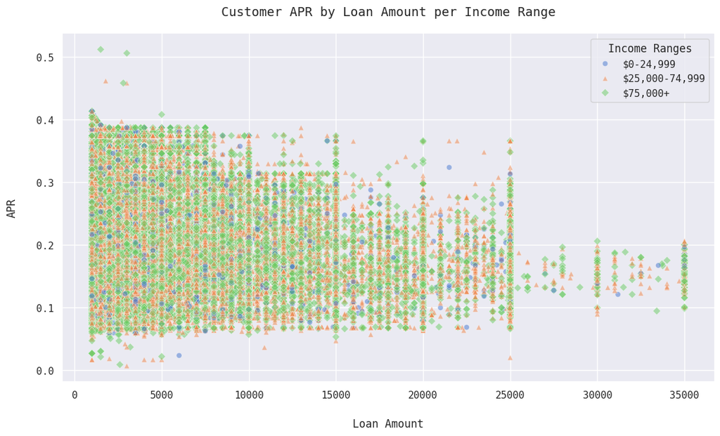

```python
plt.figure(figsize=(13, 7))
sns.scatterplot(data=chart_df, x='Amount', y='APR', hue='Income', style='Income', alpha=0.5,
                markers=IR_marker_styles, palette='muted')
plt.title('Customer APR by Loan Amount per Income Range')
plt.xlabel('Loan Amount', labelpad=20)
plt.ylabel('APR', labelpad=20)
plt.legend(title='Income Ranges')
plt.show()
```

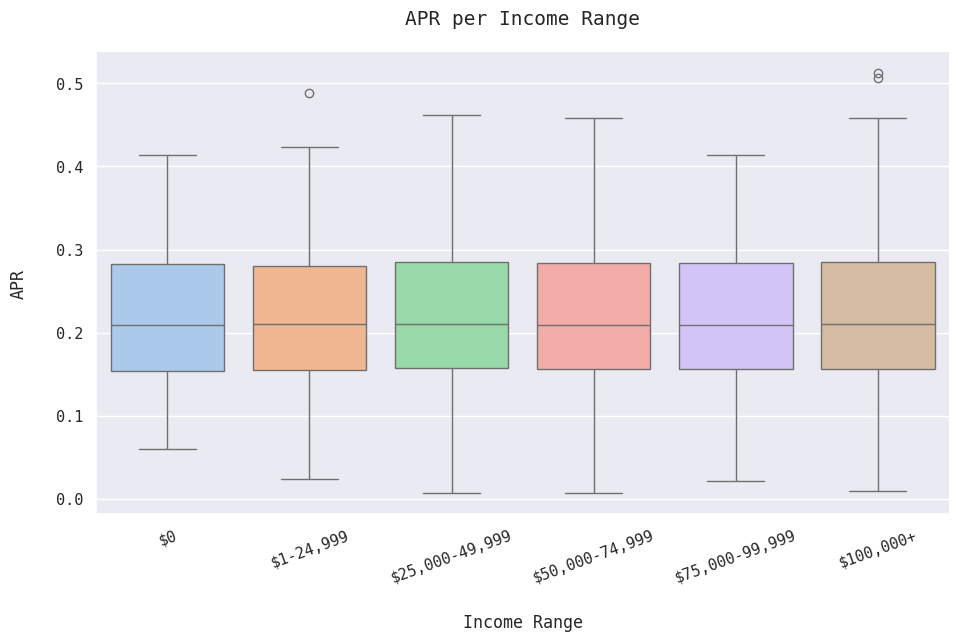

```python
plt.figure(figsize=(11,6))
sns.boxplot(data=anova_df, x='IncomeRange', y='BorrowerAPR', palette='pastel')
plt.xticks(rotation=20)
plt.title('APR per Income Range')
plt.xlabel('Income Range', labelpad=20)
plt.ylabel('APR', labelpad=20)
plt.show()
```

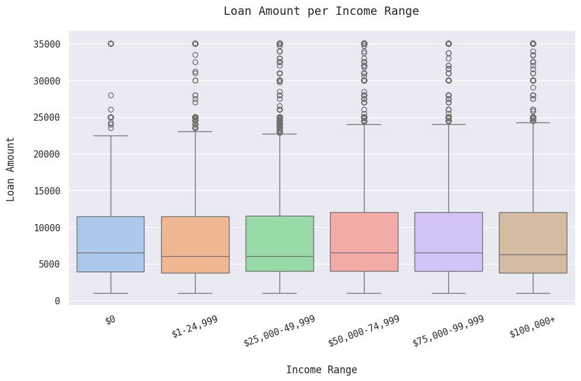

```python
plt.figure(figsize=(11,6))
sns.boxplot(data=anova_df, x='IncomeRange', y='LoanOriginalAmount', palette='pastel')
plt.xticks(rotation=20)
plt.title('Loan Amount per Income Range')
plt.xlabel('Income Range', labelpad=20)
plt.ylabel('Loan Amount', labelpad=20)
plt.show()
```

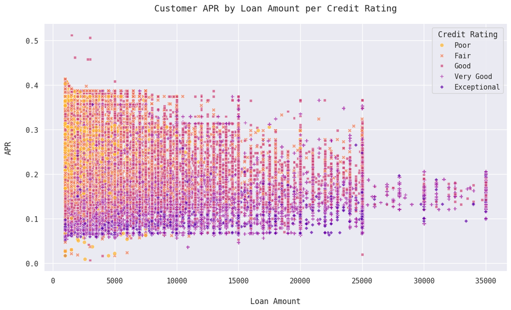

```python
plt.figure(figsize=(13, 7))
sns.scatterplot(data=chart_df, x='Amount', y='APR', hue='CreditScore', style='CreditScore', alpha=0.7,
                palette='plasma_r')
plt.title('Customer APR by Loan Amount per Credit Rating')
plt.xlabel('Loan Amount', labelpad=20)
plt.ylabel('APR', labelpad=20)
plt.legend(title='Credit Rating')
plt.show()
```

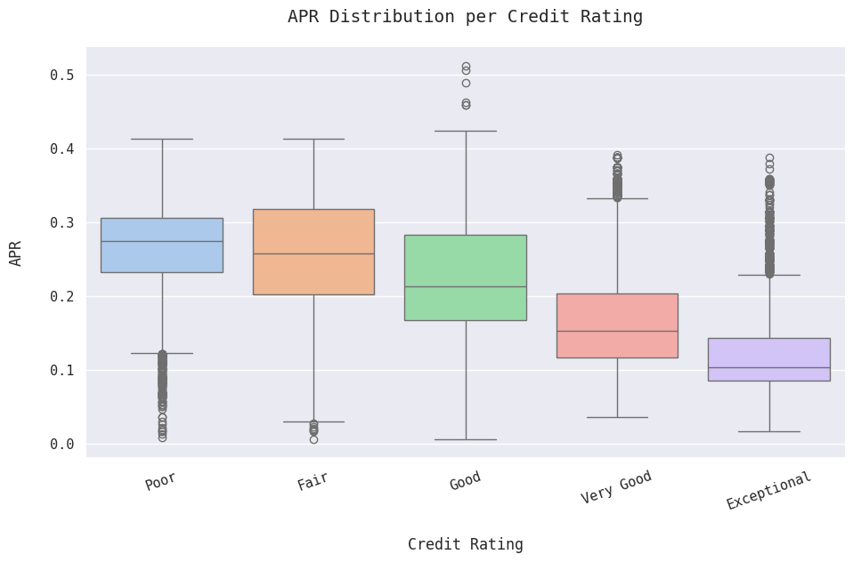

```python
plt.figure(figsize=(11,6))
sns.boxplot(data=anova_df, x='CreditScore', y='BorrowerAPR', palette='pastel')
plt.xticks(rotation=20)
plt.title('APR Distribution per Credit Rating')
plt.xlabel('Credit Rating', labelpad=20)
plt.ylabel('APR', labelpad=20)
plt.show()
```

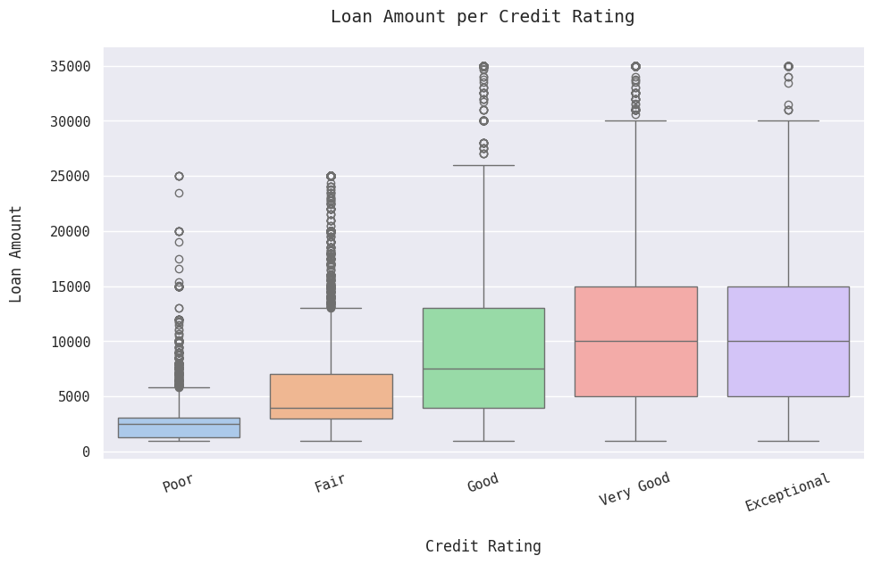

```python
plt.figure(figsize=(11,6))
sns.boxplot(data=anova_df, x='CreditScore', y='LoanOriginalAmount', palette='pastel')
plt.xticks(rotation=20)
plt.title('Loan Amount per Credit Rating')
plt.xlabel('Credit Rating', labelpad=20)
plt.ylabel('Loan Amount', labelpad=20)
plt.show()
```

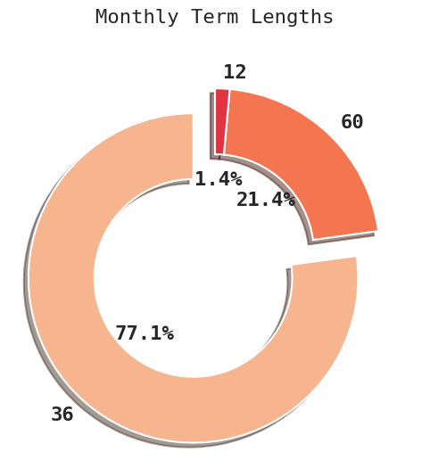

```python
# Doughnut chart code
pie_labels = ['36', '60', '12']
pie_sizes = [87224, 24228, 1614]
pie_explode = (0.2, 0, 0)
pie_bold_font = FontProperties(weight='bold', size=16)

plt.figure(figsize=(10,6))
plt.pie(pie_sizes, explode=pie_explode, labels=pie_labels, autopct='%1.1f%%', shadow=True, startangle=90,
       wedgeprops={'width':.4, 'linewidth':1.5}, textprops={'fontproperties': pie_bold_font},
                   pctdistance=.45)
plt.title('Monthly Term Lengths', size=16)
plt.show()
```

```python
prosper_score
```

| ProsperScore | LoanOriginalAmount | BorrowerAPR | CurrentDelinquencies | AmountDelinquent | OpenCreditLines | CreditScore | DebtToIncomeRatio | BankcardUtilization | Recommendations |
| --- | --- | --- | --- | --- | --- | --- | --- | --- | --- |
| 1.0 | 6472.01 | 0.22 | 1.02 | 1143.72 | 8.85 | 685.44 | 0.51 | 0.55 | 0.04 |
| 2.0 | 6251.26 | 0.22 | 0.85 | 1146.65 | 8.45 | 682.28 | 0.31 | 0.53 | 0.01 |
| 3.0 | 6451.83 | 0.22 | 0.97 | 1128.54 | 8.55 | 682.31 | 0.32 | 0.53 | 0.01 |
| 4.0 | 6219.06 | 0.22 | 0.87 | 1020.58 | 8.44 | 683.33 | 0.30 | 0.54 | 0.01 |
| 5.0 | 6315.71 | 0.22 | 0.82 | 961.02 | 8.46 | 683.46 | 0.29 | 0.53 | 0.01 |
| 6.0 | 6107.96 | 0.22 | 0.91 | 1007.98 | 8.41 | 680.04 | 0.27 | 0.54 | 0.01 |
| 7.0 | 6307.37 | 0.22 | 0.92 | 1206.76 | 8.49 | 683.16 | 0.24 | 0.53 | 0.01 |
| 8.0 | 6374.04 | 0.22 | 0.85 | 1048.13 | 8.42 | 681.37 | 0.22 | 0.53 | 0.02 |
| 9.0 | 6119.41 | 0.22 | 0.98 | 933.71 | 8.48 | 680.89 | 0.19 | 0.53 | 0.03 |
| 10.0 | 6139.82 | 0.22 | 0.82 | 888.99 | 8.66 | 684.64 | 0.18 | 0.53 | 0.03 |
| 11.0 | 6159.63 | 0.22 | 0.96 | 920.82 | 8.56 | 676.67 | 0.20 | 0.52 | 0.03 |